# Capstone Project_Credit Scoring R. Gowri Lakshani

Phase 1: Data Management

1. Understand Datasets

```r
# Importing required libraries
library(dplyr)
library(ggplot2)
library(tidyr)
library(forcats)
library(purrr)
library(patchwork)
library(ggridges)

# Import datasets
customer_credit <- read.csv(file.choose(), header = TRUE)
customer_info <- read.csv(file.choose(), header = TRUE)
customer_profile<- read.csv(file.choose(), header = TRUE)
```

Using a custom function to quickly check the structure, dimensions, and summary statistics of each dataset.

```r
# Function to explore datasets
data_check <- function(data) {
  print(head(data)); cat("Dimensions:", paste(dim(data), collapse = " x "), "\n")
  print(str(data)); print(summary(data))
}

# Apply the function to each dataset
data_check(customer_credit)
```

```
##   custid debtinc creddebt othdebt preloan
## 1      1   12.34    13.26    5.88       2
## 2      2   18.65     2.12    5.13       1
## 3      3    7.22     3.31    3.65       1
## 4      4    6.15     2.95    2.34       1
## 5      5   20.64     2.67    4.07       2
## 6      6   12.44     3.06    2.57       2
## Dimensions: 6993 x 5
## 'data.frame':    6993 obs. of  5 variables:
##  $ custid  : int  1 2 3 4 5 6 7 8 9 10 ...
##  $ debtinc : num  12.34 18.65 7.22 6.15 20.64 ...
##  $ creddebt: num  13.26 2.12 3.31 2.95 2.67 ...
##  $ othdebt : num  5.88 5.13 3.65 2.34 4.07 ...
##  $ preloan : int  2 1 1 1 2 2 2 1 2 2 ...
## NULL
##      custid        debtinc         creddebt         othdebt
##  Min.   :   1   Min.   : 0.66   Min.   : 0.040   Min.   : 0.040
##  1st Qu.:1746   1st Qu.: 7.52   1st Qu.: 1.690   1st Qu.: 2.070
##  Median :3494   Median :11.31   Median : 2.630   Median : 3.030
##  Mean   :3494   Mean   :12.75   Mean   : 3.036   Mean   : 4.058
##  3rd Qu.:5242   3rd Qu.:16.77   3rd Qu.: 3.690   3rd Qu.: 4.910
##  Max.   :6990   Max.   :45.33   Max.   :22.490   Max.   :28.740
##                 NA's   :1                        NA's   :4
##     preloan
##  Min.   : 1.000
##  1st Qu.: 1.000
##  Median : 1.000
##  Mean   : 1.498
##  3rd Qu.: 2.000
##  Max.   :11.000
##  NA's   :3
```

```r
data_check(customer_info)
```

```
##   custid veh house selfemp account deposit emp address branch ref
## 1      1   2     1       2       1       2  18      12      1   2
## 2      2   2     1       1       2       1  11       7      1   2
## 3      3   1     2       1       1       1  16      15      1   1
## 4      4   1     2       1       1       2  15      14      2   1
## 5      5   2     1       1       1       1   2       1      2   2
## 6      6   2     2       1       1       2   5       5      1   2
## Dimensions: 6990 x 10
## 'data.frame':    6990 obs. of  10 variables:
##  $ custid : int  1 2 3 4 5 6 7 8 9 10 ...
##  $ veh    : int  2 2 1 1 2 2 2 2 2 2 ...
##  $ house  : int  1 1 2 2 1 2 1 1 2 1 ...
##  $ selfemp: int  2 1 1 1 1 1 2 1 2 1 ...
##  $ account: int  1 2 1 1 1 1 2 1 2 1 ...
##  $ deposit: int  2 1 1 2 1 2 2 2 2 1 ...
##  $ emp    : int  18 11 16 15 2 5 21 12 3 1 ...
##  $ address: int  12 7 15 14 1 5 10 12 4 13 ...
##  $ branch : int  1 1 1 2 2 1 2 2 2 1 ...
##  $ ref    : int  2 2 1 1 2 2 2 1 2 2 ...
## NULL
##      custid          veh             house          selfemp
##  Min.   :   1   Min.   : 1.000   Min.   :1.000   Min.   : 1.000
##  1st Qu.:1748   1st Qu.: 1.000   1st Qu.:1.000   1st Qu.: 1.000
##  Median :3496   Median : 2.000   Median :1.000   Median : 1.000
##  Mean   :3496   Mean   : 1.509   Mean   :1.492   Mean   : 1.497
##  3rd Qu.:5243   3rd Qu.: 2.000   3rd Qu.:2.000   3rd Qu.: 2.000
##  Max.   :6990   Max.   :22.000   Max.   :2.000   Max.   :11.000
##     account         deposit            emp            address
##  Min.   :1.000   Min.   : 1.000   Min.   : 0.000   Min.   : 0.000
##  1st Qu.:1.000   1st Qu.: 1.000   1st Qu.: 3.000   1st Qu.: 3.000
##  Median :1.000   Median : 2.000   Median : 8.000   Median : 7.000
##  Mean   :1.495   Mean   : 1.511   Mean   : 8.892   Mean   : 8.774
##  3rd Qu.:2.000   3rd Qu.: 2.000   3rd Qu.:13.000   3rd Qu.:13.000
##  Max.   :2.000   Max.   :11.000   Max.   :32.000   Max.   :35.000
##      branch           ref
##  Min.   :1.000   Min.   :1.000
##  1st Qu.:1.000   1st Qu.:1.000
##  Median :1.000   Median :2.000
##  Mean   :1.486   Mean   :1.501
##  3rd Qu.:2.000   3rd Qu.:2.000
##  Max.   :2.000   Max.   :2.000
```

```r
data_check(customer_profile)
```

```
##   custid age gender ms child zone bad
## 1      1   2      1  2     2    7   1
## 2      2   2      2  1     1    5   0
## 3      3   1      1  2     1   15   0
## 4      4   2      1  1     1    3   0
## 5      5   2      2  1     1   20   0
## 6      6   1      2  1     1    5   0
## Dimensions: 6990 x 7
## 'data.frame':    6990 obs. of  7 variables:
##  $ custid: int  1 2 3 4 5 6 7 8 9 10 ...
##  $ age   : int  2 2 1 2 2 1 2 1 2 2 ...
##  $ gender: int  1 2 1 1 2 2 1 2 1 1 ...
##  $ ms    : int  2 1 2 1 1 1 2 1 2 2 ...
##  $ child : int  2 1 1 1 1 1 1 1 1 1 ...
##  $ zone  : int  7 5 15 3 20 5 3 1 8 17 ...
##  $ bad   : int  1 0 0 0 0 0 0 0 0 0 ...
## NULL
##      custid          age            gender            ms            child
##  Min.   :   1   Min.   :1.000   Min.   :1.000   Min.   :1.000   Min.   :1.00
##  1st Qu.:1748   1st Qu.:1.000   1st Qu.:1.000   1st Qu.:1.000   1st Qu.:1.00
##  Median :3496   Median :2.000   Median :1.000   Median :1.000   Median :1.00
##  Mean   :3496   Mean   :1.979   Mean   :1.499   Mean   :1.497   Mean   :1.25
##  3rd Qu.:5243   3rd Qu.:3.000   3rd Qu.:2.000   3rd Qu.:2.000   3rd Qu.:1.00
##  Max.   :6990   Max.   :3.000   Max.   :2.000   Max.   :2.000   Max.   :2.00
##       zone           bad
##  Min.   : 1.0   Min.   :0.0000
##  1st Qu.: 5.0   1st Qu.:0.0000
##  Median :10.0   Median :0.0000
##  Mean   :10.4   Mean   :0.1323
##  3rd Qu.:15.0   3rd Qu.:0.0000
##  Max.   :20.0   Max.   :1.0000
```

```r
# Checking for duplicates
lapply(list(customer_credit, customer_info, customer_profile),
       \(data) data %>% filter(custid %in% custid[duplicated(custid)]))
```

```
## [[1]]
##   custid debtinc creddebt othdebt preloan
## 1     22   10.28     0.95    3.14       2
## 2     22      NA     0.06    0.12      NA
## 3     73   15.67     4.67   10.20       1
## 4     73    0.66     0.51    0.04      NA
## 5    394   19.53     9.56    6.97       2
## 6    394    1.01     0.04    0.10      NA
##
## [[2]]
##  [1] custid  veh     house   selfemp account deposit emp     address branch
## [10] ref
## <0 rows> (or 0-length row.names)
##
## [[3]]
## [1] custid age    gender ms     child  zone   bad
## <0 rows> (or 0-length row.names)
```

- The customer_credit dataset has duplicate custid rows with inconsistent data (some rows have NA values).

```r
# Removing incomplete duplicate rows from customer_credit dataset to ensure data quality.

cleaned_customer_credit <- customer_credit %>%
  group_by(custid) %>%
  filter(if (n() == 1) TRUE else complete.cases(pick(everything()))) %>%
  ungroup()

cleaned_customer_credit %>% filter(custid %in% custid[duplicated(custid)])
```

```
## # A tibble: 0 × 5
## # ℹ 5 variables: custid <int>, debtinc <dbl>, creddebt <dbl>, othdebt <dbl>,
## #   preloan <int>
```

```r
sum(duplicated(cleaned_customer_credit$custid))
```

```
## [1] 0
```

2. Merging 3 structured data sets and creating a master data

```r
master_data <- full_join(full_join(customer_info, cleaned_customer_credit, by = "custid"),
                         customer_profile, by = "custid")
head(master_data)
```

```
##   custid veh house selfemp account deposit emp address branch ref debtinc
## 1      1   2     1       2       1       2  18      12      1   2   12.34
## 2      2   2     1       1       2       1  11       7      1   2   18.65
## 3      3   1     2       1       1       1  16      15      1   1    7.22
## 4      4   1     2       1       1       2  15      14      2   1    6.15
## 5      5   2     1       1       1       1   2       1      2   2   20.64
## 6      6   2     2       1       1       2   5       5      1   2   12.44
##   creddebt othdebt preloan age gender ms child zone bad
## 1    13.26    5.88       2   2      1  2     2    7   1
## 2     2.12    5.13       1   2      2  1     1    5   0
## 3     3.31    3.65       1   1      1  2     1   15   0
## 4     2.95    2.34       1   2      1  1     1    3   0
## 5     2.67    4.07       2   2      2  1     1   20   0
## 6     3.06    2.57       2   1      2  1     1    5   0
```

```r
dim(master_data)
```

```
## [1] 6990   20
```

3. Data cleaning

```r
# Checking missing values
colSums(is.na(master_data))
```

```
##   custid      veh    house  selfemp  account  deposit      emp  address
##        0        0        0        0        0        0        0        0
##   branch      ref  debtinc creddebt  othdebt  preloan      age   gender
##        0        0        0        0        4        0        0        0
##       ms    child     zone      bad
##        0        0        0        0
```

- There are only 4 NA values in one column (othdebt).
- Removing rows with missing values as they account for a negligible proportion of the dataset and are unlikely to impact analysis.

```r
master_data <- na.omit(master_data)
dim(master_data)
```

```
## [1] 6986   20
```

Checking duplicated values

```r
master_data%>% filter(custid %in% custid[duplicated(custid)])
```

```
##  [1] custid   veh      house    selfemp  account  deposit  emp      address
##  [9] branch   ref      debtinc  creddebt othdebt  preloan  age      gender
## [17] ms       child    zone     bad
## <0 rows> (or 0-length row.names)
```

```r
colSums(is.na(master_data))
```

```
##   custid      veh    house  selfemp  account  deposit      emp  address
##        0        0        0        0        0        0        0        0
##   branch      ref  debtinc creddebt  othdebt  preloan      age   gender
##        0        0        0        0        0        0        0        0
##       ms    child     zone      bad
##        0        0        0        0
```

```r
str(master_data)
```

```
## 'data.frame':    6986 obs. of  20 variables:
##  $ custid  : int  1 2 3 4 5 6 7 8 9 10 ...
##  $ veh     : int  2 2 1 1 2 2 2 2 2 2 ...
##  $ house   : int  1 1 2 2 1 2 1 1 2 1 ...
##  $ selfemp : int  2 1 1 1 1 1 2 1 2 1 ...
##  $ account : int  1 2 1 1 1 1 2 1 2 1 ...
##  $ deposit : int  2 1 1 2 1 2 2 2 2 1 ...
##  $ emp     : int  18 11 16 15 2 5 21 12 3 1 ...
##  $ address : int  12 7 15 14 1 5 10 12 4 13 ...
##  $ branch  : int  1 1 1 2 2 1 2 2 2 1 ...
##  $ ref     : int  2 2 1 1 2 2 2 1 2 2 ...
##  $ debtinc : num  12.34 18.65 7.22 6.15 20.64 ...
##  $ creddebt: num  13.26 2.12 3.31 2.95 2.67 ...
##  $ othdebt : num  5.88 5.13 3.65 2.34 4.07 ...
##  $ preloan : int  2 1 1 1 2 2 2 1 2 2 ...
##  $ age     : int  2 2 1 2 2 1 2 1 2 2 ...
##  $ gender  : int  1 2 1 1 2 2 1 2 1 1 ...
##  $ ms      : int  2 1 2 1 1 1 2 1 2 2 ...
##  $ child   : int  2 1 1 1 1 1 1 1 1 1 ...
##  $ zone    : int  7 5 15 3 20 5 3 1 8 17 ...
##  $ bad     : int  1 0 0 0 0 0 0 0 0 0 ...
##  - attr(*, "na.action")= 'omit' Named int [1:4] 17 164 1109 3035
##   ..- attr(*, "names")= chr [1:4] "17" "164" "1109" "3035"
```

Checking unique values and frequencies

```r
# List of categorical variables to analyze
columns_to_analyze <- c("preloan", "veh", "house", "selfemp", "account",
                        "deposit", "branch", "ref", "gender", "ms",
                        "child", "bad")

# Print unique values and their frequencies in a clean tabular format
for (col in columns_to_analyze) {
  freq_table <- table(master_data[[col]])
  cat(sprintf("%-10s | %-20s | %s\n", col,
              paste(names(freq_table), collapse = ", "),
              paste(freq_table, collapse = ", ")))
}
```

```
## preloan    | 1, 2, 11             | 3516, 3469, 1
## veh        | 1, 2, 11, 22         | 3456, 3528, 1, 1
## house      | 1, 2                 | 3546, 3440
## selfemp    | 1, 2, 11             | 3521, 3464, 1
## account    | 1, 2                 | 3528, 3458
## deposit    | 1, 2, 11             | 3424, 3561, 1
## branch     | 1, 2                 | 3589, 3397
## ref        | 1, 2                 | 3485, 3501
## gender     | 1, 2                 | 3499, 3487
## ms         | 1, 2                 | 3511, 3475
## child      | 1, 2                 | 5240, 1746
## bad        | 0, 1                 | 6062, 924
```

- Output shows that only 1 occurrence of an error value in each variable (preloan, veh, selfemp, deposit) and makes it clear that the issue affects only a very small fraction of the data.
- Therefore, it is more appropriate to correct these few entries.

Replacing the incorrect values since those appear only a few times

```r
# Defining the replacements as a named list
replacements <- list(
  preloan = c("11" = 1),
  veh = c("11" = 1, "22" = 2),
  selfemp = c("11" = 1),
  deposit = c("11" = 1)
)

# Apply replacements
master_data[names(replacements)] <- lapply(names(replacements), function(col) {
  replace(master_data[[col]], master_data[[col]] %in% as.numeric(names(replacements[[col]])),
          as.numeric(unname(replacements[[col]])))
})
```

Converting categorical variables into factors

```r
# Defining a mapping of columns to their factor levels and labels
factor_mapping <- list(
  age = c("<32", "32-48", ">48"),
  gender = c("Female", "Male"),
  ms = c("Single", "Married"),
  child = c("Zero or One", "More than One"),
  veh = c("No Vehicle", "Own Vehicle"),
  house = c("No House", "Own House"),
  selfemp = c("Not Self Employed", "Self Employed"),
  account = c("Other Bank", "Same Bank (CASA)"),
  deposit = c("No Deposit", "Has Deposit"),
  branch = c("Other Branch", "Nearest Branch"),
  ref = c("No Reference", "Internal Reference"),
  preloan = c("First Loan", "Not First Loan"),
  zone = NULL,
  bad = NULL
)

# Convert specified columns to factors with labels
master_data <- master_data %>%
  mutate(across(all_of(names(factor_mapping)), ~ {
    if (is.null(factor_mapping[[cur_column()]])) {
      # Convert to factor without labels
      as.factor(.)
    } else {
      # Convert to factor with specified labels
      factor(., labels = factor_mapping[[cur_column()]])
    }
  }))
```

Converting Employment & Address columns to numeric

```r
numeric_columns <- c("emp", "address")

master_data <- master_data %>%
  mutate(across(all_of(numeric_columns), as.numeric))

str(master_data)
```

```
## 'data.frame':    6986 obs. of  20 variables:
##  $ custid  : int  1 2 3 4 5 6 7 8 9 10 ...
##  $ veh     : Factor w/ 2 levels "No Vehicle","Own Vehicle": 2 2 1 1 2 2 2 2 2 2 ...
##  $ house   : Factor w/ 2 levels "No House","Own House": 1 1 2 2 1 2 1 1 2 1 ...
##  $ selfemp : Factor w/ 2 levels "Not Self Employed",..: 2 1 1 1 1 1 2 1 2 1 ...
##  $ account : Factor w/ 2 levels "Other Bank","Same Bank (CASA)": 1 2 1 1 1 1 2 1 2 1 ...
##  $ deposit : Factor w/ 2 levels "No Deposit","Has Deposit": 2 1 1 2 1 2 2 2 2 1 ...
##  $ emp     : num  18 11 16 15 2 5 21 12 3 1 ...
##  $ address : num  12 7 15 14 1 5 10 12 4 13 ...
##  $ branch  : Factor w/ 2 levels "Other Branch",..: 1 1 1 2 2 1 2 2 2 1 ...
##  $ ref     : Factor w/ 2 levels "No Reference",..: 2 2 1 1 2 2 2 1 2 2 ...
##  $ debtinc : num  12.34 18.65 7.22 6.15 20.64 ...
##  $ creddebt: num  13.26 2.12 3.31 2.95 2.67 ...
##  $ othdebt : num  5.88 5.13 3.65 2.34 4.07 ...
##  $ preloan : Factor w/ 2 levels "First Loan","Not First Loan": 2 1 1 1 2 2 2 1 2 2 ...
##  $ age     : Factor w/ 3 levels "<32","32-48",..: 2 2 1 2 2 1 2 1 2 2 ...
##  $ gender  : Factor w/ 2 levels "Female","Male": 1 2 1 1 2 2 1 2 1 1 ...
##  $ ms      : Factor w/ 2 levels "Single","Married": 2 1 2 1 1 1 2 1 2 2 ...
##  $ child   : Factor w/ 2 levels "Zero or One",..: 2 1 1 1 1 1 1 1 1 1 ...
##  $ zone    : Factor w/ 20 levels "1","2","3","4",..: 7 5 15 3 20 5 3 1 8 17 ...
##  $ bad     : Factor w/ 2 levels "0","1": 2 1 1 1 1 1 1 1 1 1 ...
##  - attr(*, "na.action")= 'omit' Named int [1:4] 17 164 1109 3035
##   ..- attr(*, "names")= chr [1:4] "17" "164" "1109" "3035"
```

- Categorical variables are converted into factors with meaningful labels (e.g., “Male”/“Female”) to improve interpretability and analysis readiness.
- Variables like emp (employment duration) and address are converted to numeric format to enable mathematical operations.
- Properly formatted data ensures compatibility with models, visualizations, and statistical tools.
4. Checking outliers

IQR-Based Method

```r
# Defining a function to detect IQR-based outliers
detect_outliers <- function(x) {
  q1 <- quantile(x, 0.25, na.rm = TRUE)
  q3 <- quantile(x, 0.75, na.rm = TRUE)
  iqr <- q3 - q1
  lower_bound <- q1 - 1.5 * iqr
  upper_bound <- q3 + 1.5 * iqr
  return(x < lower_bound | x > upper_bound)
}

# List of variables to check for outliers
numeric_vars <- c("emp", "address", "debtinc", "creddebt", "othdebt")

# Creating a list to store outlier flags
outlier_flags_list <- lapply(numeric_vars, function(col) {
  detect_outliers(master_data[[col]])
})

names(outlier_flags_list) <- paste0(numeric_vars)

# Count and display the number of outliers for each variable
outlier_counts <- sapply(outlier_flags_list, sum, na.rm = TRUE)
outlier_counts
```

```
##      emp  address  debtinc creddebt  othdebt
##       65       40      137      372      515
```

- The data set contains varying numbers of outliers across different numeric variables.
- Specifically, othdebt has the highest number of outliers (515), followed by creddebt (372), debtinc (137), emp (65), and address (40).

Boxplots for visualizing outliers

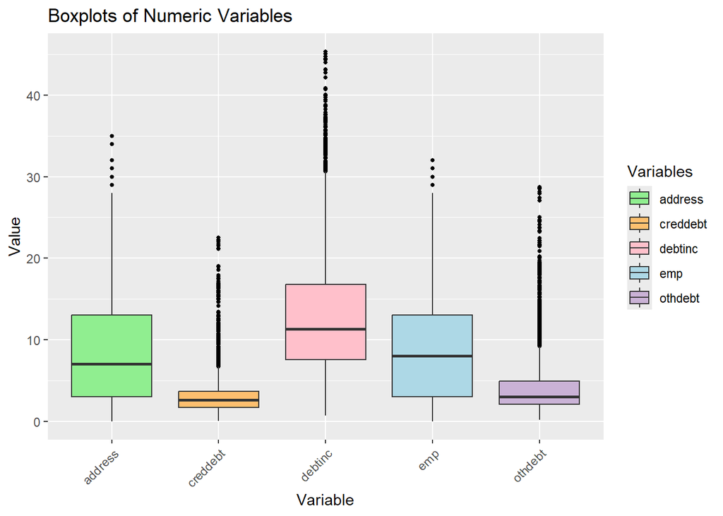

```r
# Reshaping data to long format for ggplot
long_data <- master_data %>%
  select(all_of(c("emp", "address", "debtinc", "creddebt", "othdebt"))) %>%
  pivot_longer(cols = everything(), names_to = "variable", values_to = "value")

# Defining a custom color palette
custom_colors <- c(
  "emp" = "lightblue",
  "address" = "lightgreen",
  "debtinc" = "pink",
  "creddebt" = "#fdbf6f",
  "othdebt" = "#cab2d6"
)

# Creating boxplots using ggplot2
ggplot(long_data, aes(x = variable, y = value, fill = variable)) +
  geom_boxplot(outlier.color = "black", outlier.size = 1) +
  labs(title = "Boxplots of Numeric Variables",
       x = "Variable",
       y = "Value",
       fill = "Variable") +
  theme(axis.text.x = element_text(angle = 45, hjust = 1)) +
  scale_fill_manual(values = custom_colors) +
  guides(fill = guide_legend(title = "Variables"))
```

- The boxplots provide a visual summary of the distribution of each numeric variable (address, creddebt, debtinc, emp, othdebt).
- Address (Years at current address): Most values cluster around 3–13 years, with a few outliers extending up to 35 years.
- Creddebt (Balance CC debt): Values are tightly clustered around 1-3 years, indicating low credit card debt for most customers, with some outliers extends beyond 20.
- Debtinc (Loan to income ratio): The majority of values fall within the 7–16 range, but there is a significant tail of outliers extending beyond 30.
- Emp (Years with current employer): Values are concentrated between 3–13 years, with a few outliers exceeding 30 years.
- Othdebt (Any other debt): Similar to emp, most values are below 5, but there is a long tail of outliers extending up to 30.

Evaluating the Impact of Outliers

```r
# 1. Extract Rows with Outliers

# Function to extract outliers (above 95th percentile)
extract_outliers <- function(data, var) {
   data[data[[var]] > quantile(data[[var]], 0.95, na.rm = TRUE), ]
   }

# Extract outliers for all numeric variables
outliers_list <- lapply(numeric_vars, function(var) {
   extract_outliers(master_data, var)
    })

# Combine all outlier rows into one dataset
all_outliers <- do.call(rbind, outliers_list) %>%
  distinct()

head(all_outliers)
```

```
##    custid         veh     house           selfemp          account     deposit
## 13     13  No Vehicle  No House Not Self Employed       Other Bank  No Deposit
## 15     15  No Vehicle  No House     Self Employed Same Bank (CASA) Has Deposit
## 18     18  No Vehicle Own House     Self Employed       Other Bank Has Deposit
## 28     28 Own Vehicle  No House Not Self Employed Same Bank (CASA) Has Deposit
## 40     40 Own Vehicle Own House     Self Employed       Other Bank  No Deposit
## 73     73  No Vehicle  No House     Self Employed       Other Bank Has Deposit
##    emp address         branch                ref debtinc creddebt othdebt
## 13  24      15   Other Branch Internal Reference   13.65     4.03    3.57
## 15  23      16 Nearest Branch       No Reference   13.26     4.32    5.81
## 18  23      19 Nearest Branch       No Reference   12.24     1.73    5.32
## 28  25      22 Nearest Branch Internal Reference   18.31     2.09   11.56
## 40  24       6   Other Branch       No Reference    4.32     2.39    3.42
## 73  26      21   Other Branch Internal Reference   15.67     4.67   10.20
##           preloan   age gender      ms         child zone bad
## 13 Not First Loan   <32 Female  Single   Zero or One    2   0
## 15 Not First Loan 32-48   Male Married   Zero or One   18   0
## 18 Not First Loan   <32 Female Married More than One   19   0
## 28 Not First Loan   <32 Female  Single   Zero or One   18   0
## 40 Not First Loan 32-48   Male  Single   Zero or One   17   0
## 73     First Loan   >48 Female  Single   Zero or One   19   0
```

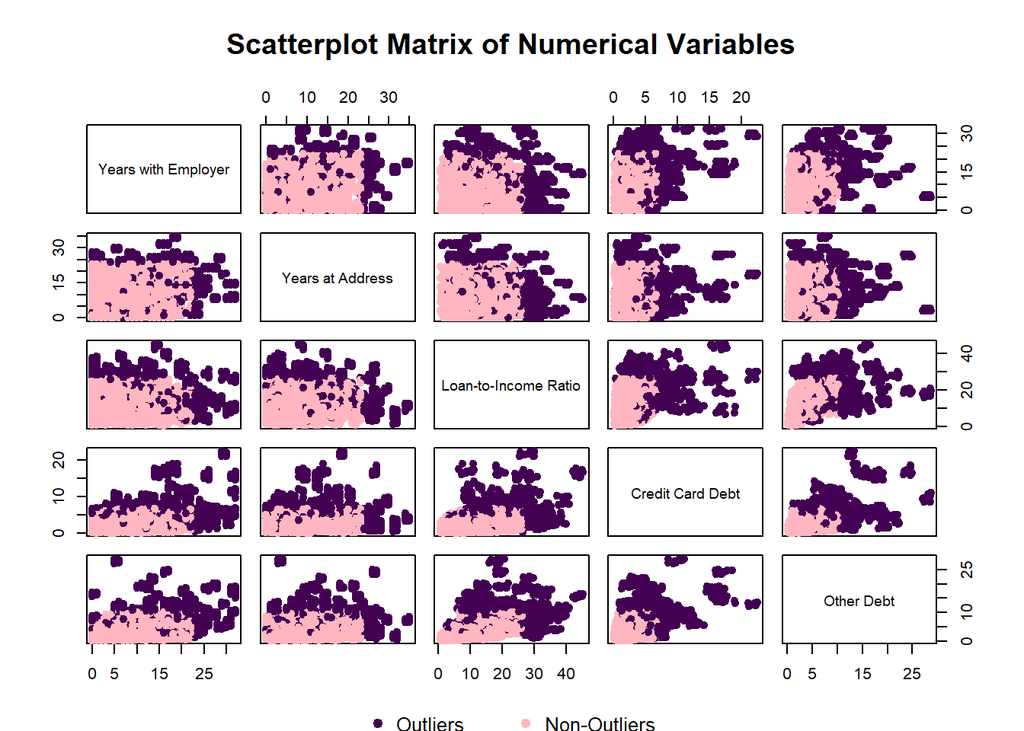

```r
# 2. Visualizing relationships between all numerical variables

# Scatterplot matrix for all numeric variables
par(mar = c(6, 4, 4, 2), xpd = TRUE)

# Scatterplot matrix
pairs(master_data[, numeric_vars],
      main = "Scatterplot Matrix of Numerical Variables",
      col = ifelse(row.names(master_data) %in% row.names(all_outliers), "#440154", "lightpink"),
      pch = 19,
      labels = c("Years with Employer", "Years at Address", "Loan-to-Income Ratio",
                 "Credit Card Debt", "Other Debt"))

legend("bottom",
       inset = -0.15,
       legend = c("Outliers", "Non-Outliers"),
       col = c("#440154", "lightpink"),
       pch = 19,
       horiz = TRUE,
       cex = 0.8,
       pt.cex = 0.8,
       bty = "n")
```

- The scatterplot shows that outliers (purple dots) tend to appear in similar regions across multiple variables, suggesting potential underlying patterns or relationships.
- Example: High loan to income ratios often correspond to high credit card debt or other debt.
- This consistent alignment of outliers across variables indicates that they are not random errors but may represent genuine high-risk customer profiles.

```r
# 3. Summary statistics for all numeric variables
summary_stats <- master_data %>%
  select(numeric_vars) %>%
  pivot_longer(cols = everything(), names_to = "Variable", values_to = "Value") %>%
  group_by(Variable) %>%
  summarise(
    Min = min(Value, na.rm = TRUE),
    Q1 = quantile(Value, 0.25, na.rm = TRUE),
    Median = median(Value, na.rm = TRUE),
    Mean = mean(Value, na.rm = TRUE),
    Q3 = quantile(Value, 0.75, na.rm = TRUE),
    Max = max(Value, na.rm = TRUE)
  )

summary_stats
```

```
## # A tibble: 5 × 7
##   Variable   Min    Q1 Median  Mean    Q3   Max
##   <chr>    <dbl> <dbl>  <dbl> <dbl> <dbl> <dbl>
## 1 address   0     3      7     8.77 13     35
## 2 creddebt  0.05  1.69   2.63  3.04  3.69  22.5
## 3 debtinc   0.69  7.53  11.3  12.8  16.8   45.3
## 4 emp       0     3      8     8.89 13     32
## 5 othdebt   0.14  2.07   3.03  4.06  4.91  28.7
```

- The summary statistics reveal significant differences between minimum, median, and maximum values for each variable.
- Example: debtinc has a median of 11.3 but a maximum of 45.3, indicating extreme values.
- The summary statistics confirm that outliers are extreme but reasonable values, representing high-risk borrowers.
- **Conclusion:** The combination of the all_outliers dataset, scatterplot matrix, and summary statistics provides a comprehensive view of outliers.
- These outputs demonstrate that most outliers are valid high-risk profiles rather than errors.
- Therefore, outliers should be retained to maintain valuable information about high-risk customers.
5. Check numerical variables for possible recoding
- Recoding numerical variables into categories helps capture non-linear relationships, simplify risk segmentation, and group similar risk profiles to make the model easier to interpret.
- Recoding thresholds were determined based on the output from summary_stats of numerical variables.

```r
# Defining a recoding function
recode_numeric <- function(x, thresholds, labels) {
  case_when(
    x < thresholds[1] ~ labels[1],
    x >= thresholds[1] & x <= thresholds[2] ~ labels[2],
    x > thresholds[2] ~ labels[3]
  ) %>%
    factor(levels = labels)
}

# Applying recoding
master_data <- master_data %>%
  mutate(
    emp_cat = recode_numeric(emp, c(3, 13), c("New", "Medium", "Long")),
    address_cat = recode_numeric(address, c(3, 13), c("New", "Medium", "Long")),
    debtinc_cat = recode_numeric(debtinc, c(7, 16), c("Low", "Moderate", "High")),
    creddebt_cat = recode_numeric(creddebt, c(2, 4), c("Low", "Moderate", "High")),
    othdebt_cat = recode_numeric(othdebt, c(2, 5), c("Low", "Moderate", "High"))
  )

head(master_data)
```

```
##   custid         veh     house           selfemp          account     deposit
## 1      1 Own Vehicle  No House     Self Employed       Other Bank Has Deposit
## 2      2 Own Vehicle  No House Not Self Employed Same Bank (CASA)  No Deposit
## 3      3  No Vehicle Own House Not Self Employed       Other Bank  No Deposit
## 4      4  No Vehicle Own House Not Self Employed       Other Bank Has Deposit
## 5      5 Own Vehicle  No House Not Self Employed       Other Bank  No Deposit
## 6      6 Own Vehicle Own House Not Self Employed       Other Bank Has Deposit
##   emp address         branch                ref debtinc creddebt othdebt
## 1  18      12   Other Branch Internal Reference   12.34    13.26    5.88
## 2  11       7   Other Branch Internal Reference   18.65     2.12    5.13
## 3  16      15   Other Branch       No Reference    7.22     3.31    3.65
## 4  15      14 Nearest Branch       No Reference    6.15     2.95    2.34
## 5   2       1 Nearest Branch Internal Reference   20.64     2.67    4.07
## 6   5       5   Other Branch Internal Reference   12.44     3.06    2.57
##          preloan   age gender      ms         child zone bad emp_cat
## 1 Not First Loan 32-48 Female Married More than One    7   1    Long
## 2     First Loan 32-48   Male  Single   Zero or One    5   0  Medium
## 3     First Loan   <32 Female Married   Zero or One   15   0    Long
## 4     First Loan 32-48 Female  Single   Zero or One    3   0    Long
## 5 Not First Loan 32-48   Male  Single   Zero or One   20   0     New
## 6 Not First Loan   <32   Male  Single   Zero or One    5   0  Medium
##   address_cat debtinc_cat creddebt_cat othdebt_cat
## 1      Medium    Moderate         High        High
## 2      Medium        High     Moderate        High
## 3        Long    Moderate     Moderate    Moderate
## 4        Long         Low     Moderate    Moderate
## 5         New        High     Moderate    Moderate
## 6      Medium    Moderate     Moderate    Moderate
```

6. Find the overall Defaulter Rate in the data

```r
overall_defaulter_rate <- mean(master_data$bad == "1", na.rm = TRUE)
overall_defaulter_rate
```

```
## [1] 0.1322645
```

- The overall defaulter rate in the dataset is approximately 13.23% , indicating that about 13.23% of the customers in the dataset are classified as defaulters.

Phase 2: Data Analysis (EDA)

1. Box-Whisker Plots for Numeric Variables by “Bad”

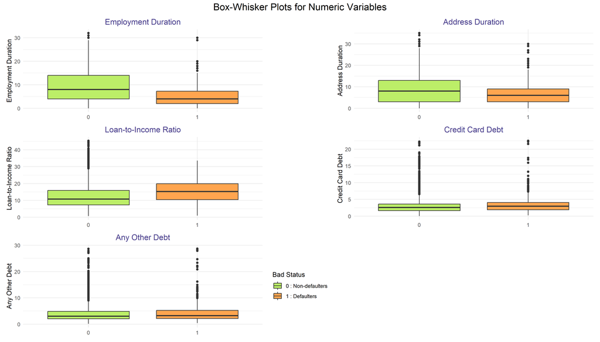

```r
# Create a mapping of numeric variable names to descriptive names
numericvar_names <- c(
  "emp" = "Employment Duration",
  "debtinc" = "Loan-to-Income Ratio",
  "address" = "Address Duration",
  "creddebt" = "Credit Card Debt",
  "othdebt" = "Any Other Debt"
)

# Create a list to store all plots
plot_list <- list()

# Loop through each numeric variable and create boxplots
for (var in numeric_vars) {
  descriptive_name <- numericvar_names[var]

  p <- ggplot(master_data, aes(x = factor(bad), y = .data[[var]], fill = factor(bad))) +
    geom_boxplot(draw_quantiles = NULL) +
    scale_fill_manual(
      values = c("0" = "darkolivegreen2", "1" = "tan1"),
      labels = c("0" = "Good", "1" = "Bad")
    ) +
    labs(title = paste(descriptive_name),
         y = descriptive_name,
         fill = NULL) +
    theme_minimal() +
    theme(
      plot.title = element_text(hjust = 0.5, color = "slateblue4"),
      axis.title.x = element_blank(),
      legend.position = "none"
    )

  # Add the plot to the list
  plot_list[[var]] <- p
}

# Combine all plots in a grid using patchwork
combined_plot <- wrap_plots(plot_list, ncol = 2)

# Add a common title for the entire combined plot
combined_plot_with_title <- combined_plot +
  plot_annotation(
    title = "Box-Whisker Plots for Numeric Variables",
    theme = theme(
      plot.title = element_text(hjust = 0.5, size = 16)
    )
  )

# Add a global legend and x-axis label
combined_plot_final <- combined_plot_with_title +
  labs(
    x = "Bad Status (0 = Good, 1 = Bad)",
    fill = "Bad Status"
  ) +
  scale_fill_manual(
    values = c("0" = "darkolivegreen2", "1" = "tan1"),
    labels = c("0" = "0 : Non-defaulters", "1" = "1 : Defaulters")
  ) +
  theme(legend.position = "right")

combined_plot_final
```

Employment Duration:

- Customers who have been employed for shorter durations tend to have higher default rates.
- The median employment duration for defaulters (Bad Status = 1) is noticeably lower than for non-defaulters (Bad Status = 0), suggesting that job instability may be a significant risk factor.

Address Duration:

- Customers with shorter durations at their current address show higher default rates.
- The median residential stability for defaulters is lower compared to non-defaulters, indicating that frequent moves might correlate with increased credit risk.

Loan to Income Ratio:

- Defaulters exhibit significantly higher loan to income ratio compared to non-defaulters, making it a strong predictor of default.
- Several outliers are observed among good customers which highlights variability in financial stability among low-risk borrowers.

Credit Card Debt:

- Both groups, defaulters and non-defaulters show similar distributions of credit card debt.
- he slight increase in median credit card debt among defaulters suggests it may still contribute to default risk, though it’s discriminative power is weaker compared to other variables.

```r
# List of All Categorical Variables (Original + Recoded)
categorical_vars <- c("age", "gender", "veh", "house", "selfemp", "account", "deposit",
                      "branch", "ref", "preloan", "ms", "child", "zone",
                      "emp_cat", "address_cat", "debtinc_cat", "creddebt_cat",
                      "othdebt_cat")

# Function to Calculate Bad Rate for a Single Variable
calculate_bad_rate <- function(data, var) {
  data %>%
    group_by(!!sym(var)) %>%
    summarise(
      Total = n(),
      Defaulters = sum(bad == "1"),
      Bad_Rate = round((Defaulters / Total) * 100, 2)
    ) %>%
    ungroup()
}

# Loop Through All Categorical Variables and Create Bad Rate Tables
bad_rate_tables <- lapply(categorical_vars, function(var) {
  bad_rate <- calculate_bad_rate(master_data, var)
  colnames(bad_rate)[1] <- var
  return(bad_rate)
})

# Combine Results into a Named List for Easy Access
names(bad_rate_tables) <- categorical_vars

# Print Bad Rate Tables for Each Variable
for (var in categorical_vars) {
  cat("\nBad Rate Table for", var, ":\n")
  print(bad_rate_tables[[var]])
}
```

```
##
## Bad Rate Table for age :
## # A tibble: 3 × 4
##   age   Total Defaulters Bad_Rate
##   <fct> <int>      <int>    <dbl>
## 1 <32    2379        327     13.8
## 2 32-48  2375        295     12.4
## 3 >48    2232        302     13.5
##
## Bad Rate Table for gender :
## # A tibble: 2 × 4
##   gender Total Defaulters Bad_Rate
##   <fct>  <int>      <int>    <dbl>
## 1 Female  3499        448     12.8
## 2 Male    3487        476     13.6
##
## Bad Rate Table for veh :
## # A tibble: 2 × 4
##   veh         Total Defaulters Bad_Rate
##   <fct>       <int>      <int>    <dbl>
## 1 No Vehicle   3457        464     13.4
## 2 Own Vehicle  3529        460     13.0
##
## Bad Rate Table for house :
## # A tibble: 2 × 4
##   house     Total Defaulters Bad_Rate
##   <fct>     <int>      <int>    <dbl>
## 1 No House   3546        444     12.5
## 2 Own House  3440        480     14.0
##
## Bad Rate Table for selfemp :
## # A tibble: 2 × 4
##   selfemp           Total Defaulters Bad_Rate
##   <fct>             <int>      <int>    <dbl>
## 1 Not Self Employed  3522        460     13.1
## 2 Self Employed      3464        464     13.4
##
## Bad Rate Table for account :
## # A tibble: 2 × 4
##   account          Total Defaulters Bad_Rate
```

[output cut: 95 more lines]

```
## Bad Rate Table for creddebt_cat :
## # A tibble: 3 × 4
##   creddebt_cat Total Defaulters Bad_Rate
##   <fct>        <int>      <int>    <dbl>
## 1 Low           2290        251     11.0
## 2 Moderate      3269        435     13.3
## 3 High          1427        238     16.7
##
## Bad Rate Table for othdebt_cat :
## # A tibble: 3 × 4
##   othdebt_cat Total Defaulters Bad_Rate
##   <fct>       <int>      <int>    <dbl>
## 1 Low          1600        191     11.9
## 2 Moderate     3691        480     13
## 3 High         1695        253     14.9
```

- Age <32 (13.8%) and >48 (13.5%) show higher defaults than 32–48 (12.4%); males (13.6%) default more than females (12.8%).
- Owning a house (14.0%) and being self-employed (13.4%) slightly increase risk; vehicle ownership and deposits show minimal impact.
- Customers from “Other Branch” (14.8%) and with “No Reference” (14.2%) have higher defaults, while nearest branch (11.5%) and internal reference (12.3%) reduce risk.
- New employees (21.6%) and new/medium-term residents (14.4%–15.1%) show higher default risk vs. long-term stability (employment 3.41%, address 7.46%).
- High debt-to-income (22.1%), credit debt (16.7%), and other debt (14.9%) significantly raise default risk, highlighting key financial stress indicators.
- Horizontal Grouped Bar Plot to visualize the Bad Rate across categorical variables.
- Categorical variables are grouped into three categories: Demographic, Credit & Financial, and Customer Relationship & Ownership.

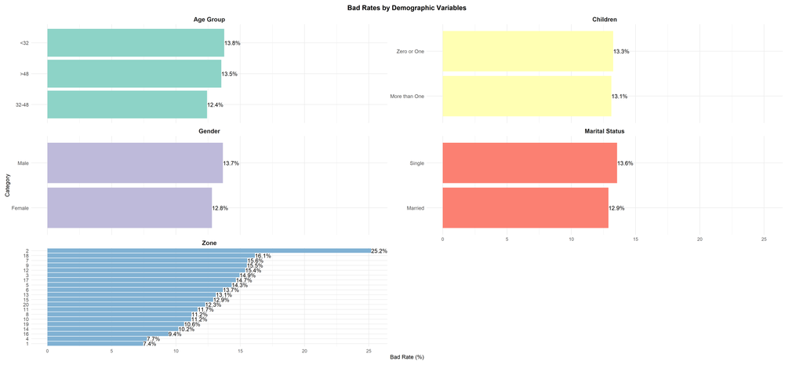

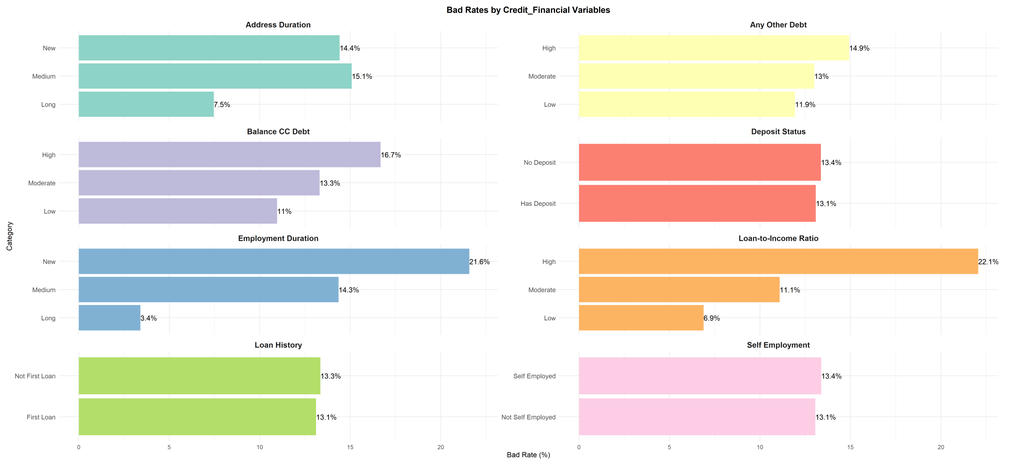

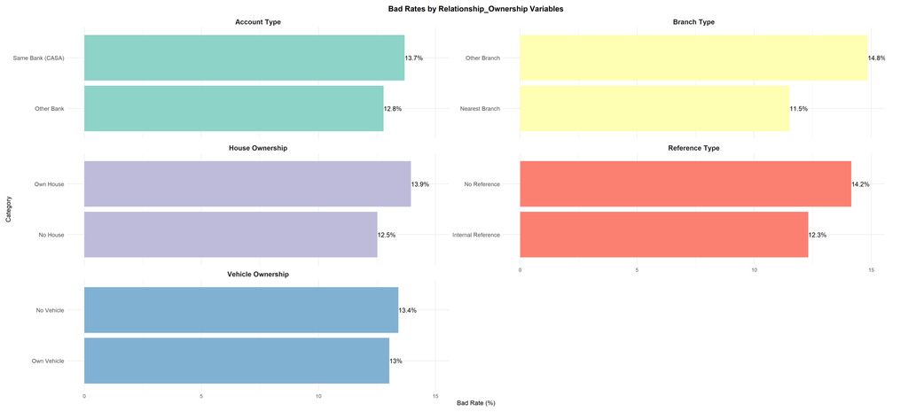

```r
# Combining all bad rate tables
bad_rate_combined <- purrr::map2_dfr(
  bad_rate_tables, categorical_vars,
  ~ .x %>%
    mutate(Variable = .y, Category = .x[[1]]) %>%
    select(Variable, Category, Bad_Rate)
)

# Defining clear names for variables
clear_names <- c(
  address_cat = "Address Duration", emp_cat = "Employment Duration",
  debtinc_cat = "Loan-to-Income Ratio", creddebt_cat = "Balance CC Debt",
  othdebt_cat = "Any Other Debt", age = "Age Group", gender = "Gender",
  veh = "Vehicle Ownership", house = "House Ownership", selfemp = "Self Employment",
  account = "Account Type", deposit = "Deposit Status", branch = "Branch Type",
  ref = "Reference Type", preloan = "Loan History", ms = "Marital Status",
  child = "Children", zone = "Zone"
)

# Defining grouping rules
grouping <- c(
  "Demographic" = "age|gender|ms|child|zone",
  "Credit & Financial" = "debtinc_cat|creddebt_cat|othdebt_cat|emp_cat|address_cat|preloan|deposit|selfemp",
  "Customer Relationship & Ownership" = "veh|house|branch|ref|account"
)

# Creating the grouping vector
grouping_vector <- unlist(lapply(names(grouping), function(group) {
  setNames(rep(group, length(unlist(strsplit(grouping[group], "\\|")))),
           unlist(strsplit(grouping[group], "\\|")))
}))

# Assigning readable names and groupings
bad_rate_combined <- bad_rate_combined %>%
  mutate(
    Clear_Variable = clear_names[Variable],
    Group = grouping_vector[Variable],
    Category = fct_reorder(as.character(Category), Bad_Rate)
  )

# Plotting function with percentage labels
plot_grouped_horizontal <- function(data, title) {
  ggplot(data, aes(x = Bad_Rate, y = Category, fill = Clear_Variable)) +
    geom_col(position = "dodge") +
    geom_text(aes(label = paste0(round(Bad_Rate, 1), "%")),
              position = position_dodge(width = 0.9),
              hjust = 0, vjust = 0.5, size = 4) +
    facet_wrap(~ Clear_Variable, scales = "free_y", ncol = 2) +
    labs(title = title, x = "Bad Rate (%)", y = "Category") +
    theme_minimal() +
    theme(
      strip.text = element_text(face = "bold", size = 12),
      axis.text.y = element_text(size = 10),
      plot.title = element_text(hjust = 0.5, face = "bold"),
      legend.position = "none",
      plot.margin = margin(10, 40, 10, 10)
    ) +
    scale_fill_brewer(palette = "Set3")
}

# Filter data by group
grouped_data <- list(
  Demographic = filter(bad_rate_combined, Group == "Demographic"),
  Credit_Financial = filter(bad_rate_combined, Group == "Credit & Financial"),
  Relationship_Ownership = filter(bad_rate_combined, Group == "Customer Relationship & Ownership")
)

# Remove empty groups
grouped_data <- grouped_data[!sapply(grouped_data, nrow) == 0]

# Generate and print plots
grouped_data %>%
  purrr::imap(~ plot_grouped_horizontal(.x, paste("Bad Rates by", .y, "Variables"))) %>%
  purrr::walk(print)
```

3. Radial Bar Charts for Mean/Median of Numeric Variables by “Bad”

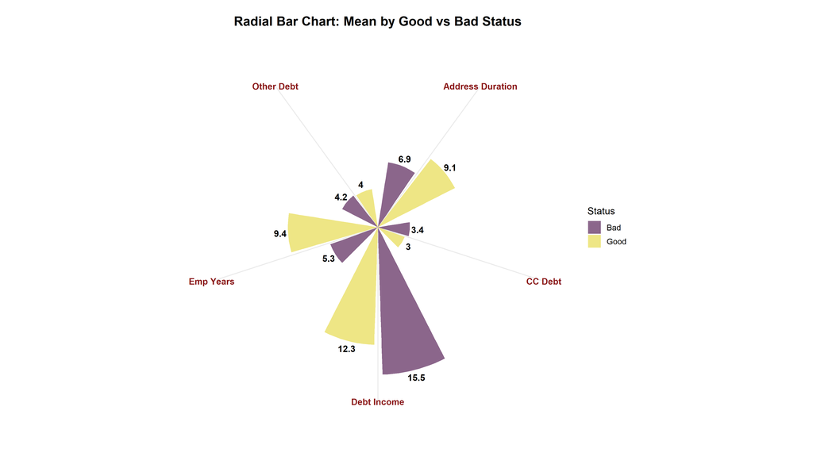

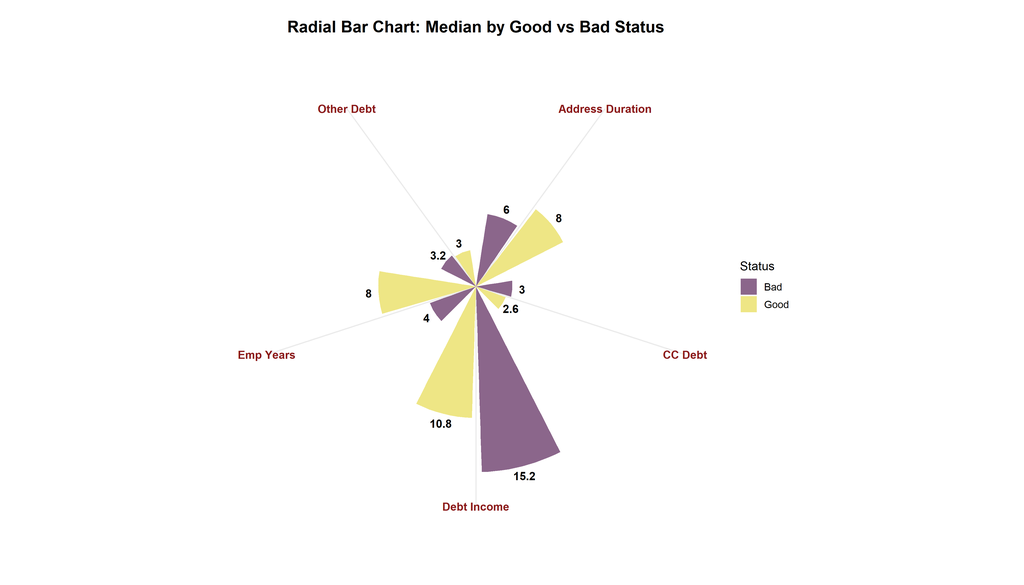

```r
# Defining readable names in the chart for numeric variables
numericvar_names2 <- c(
  "emp" = "Emp Years",
  "debtinc" = "Debt Income",
  "address" = "Address Duration",
  "creddebt" = "CC Debt",
  "othdebt" = "Other Debt"
)

# Extract variable names from the mapping
variables <- names(numericvar_names2)

# Summarize mean and median for each numeric variable by bad status
summary_stats <- master_data %>%
  group_by(bad) %>%
  summarise(across(all_of(variables), list(mean = ~ mean(.x, na.rm = TRUE),
                                           median = ~ median(.x, na.rm = TRUE)),
                   .names = "{col}_{fn}")) %>%
  pivot_longer(cols = starts_with(variables), names_to = c("Variable", "Statistic"),
               names_sep = "_", values_to = "Value") %>%
  mutate(
    Variable = factor(Variable, levels = variables),
    Statistic = factor(Statistic, levels = c("mean", "median")),
    bad = ifelse(bad == 0, "Good", "Bad"),
    Variable_Name = numericvar_names2[as.character(Variable)]
  )

# Creating Radial Bar Charts with ggplot
radial_bar_chart <- function(data, statistic) {
  stat_title <- tools::toTitleCase(statistic)

  ggplot(data %>% filter(Statistic == statistic),
         aes(x = Variable_Name, y = Value, fill = bad)) +
    geom_col(position = position_dodge(width = 0.8), width = 0.7) +
    geom_text(aes(label = round(Value, 1), y = Value+0.8),
              position = position_dodge(width = 0.8),
              size = 4, fontface = "bold") +
    coord_polar(theta = "x") +
    labs(
      title = paste("Radial Bar Chart:", stat_title, "by Good vs Bad Status"),
      x = "", y = NULL, fill = "Status"
    ) +
    scale_fill_manual(values = c("Bad" = "plum4", "Good" = "khaki2")) +
    theme_minimal(base_size = 13) +
    theme(
      axis.text.x = element_text(size = 11, angle = 0, color = "firebrick4", face= "bold", vjust = 1, hjust = 0.5),
      axis.text.y = element_blank(),
      axis.title.y = element_blank(),
      panel.grid.major.y = element_blank(),
      plot.title = element_text(hjust = 0.5, size = 16, face = "bold"),
      legend.title = element_text(size = 12),
      legend.text = element_text(size = 10),
      plot.margin = margin(20, 30, 30, 30)
    )
}

# Generate Separate Plots for Mean and Median
mean_plot <- radial_bar_chart(summary_stats, "mean")
median_plot <- radial_bar_chart(summary_stats, "median")

mean_plot
median_plot
```

- Both mean and median charts consistently show that Bad customers have higher Debt Income and lower Employment Years compared to Good customers.
- The similarity between mean and median values indicates low skewness in these numeric variables which is confirming the trend is stable, not driven by outliers.
- This comparison highlights that high debt burden and lower financial stability (less duration at employment/address) may be key indicators of credit risk.
4. Heatmap for Two Variables Showing “Bad Rate”
- Gender and Zone were chosen as both are original categorical variables and represent key demographic dimensions of customers.
- A heatmap effectively highlights regional risk patterns by gender, especially with Zone’s high category count.

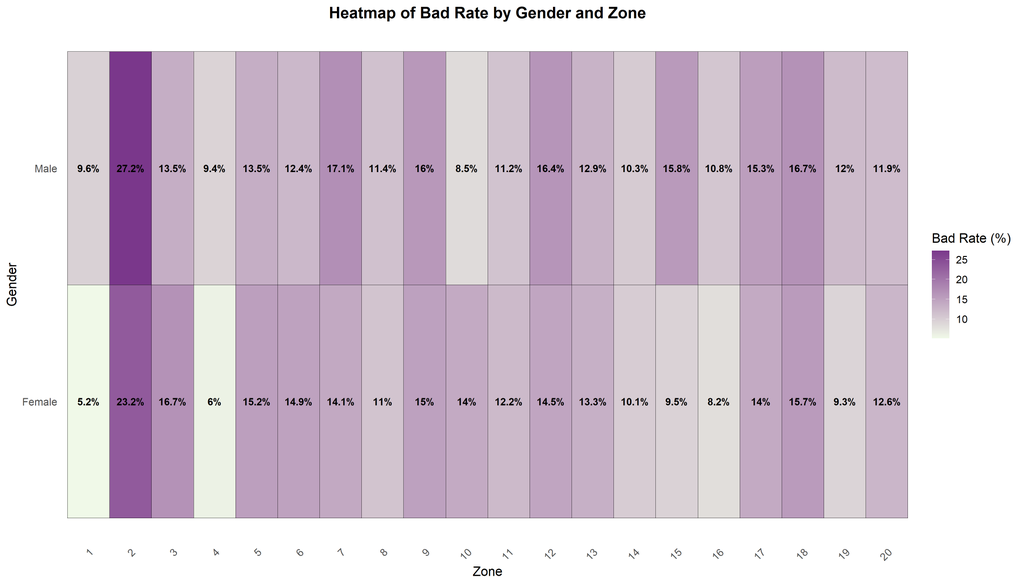

```r
heatmap_data <- master_data %>%
  group_by(gender, zone) %>%
  summarise(
    Total = n(),
    Defaulters = sum(bad == 1),
    Bad_Rate = round((Defaulters / Total) * 100, 1),
    .groups = "drop"
  )

heatmap_plot <- ggplot(heatmap_data, aes(x = zone, y = gender, fill = Bad_Rate)) +
  geom_tile(color = "black") +
  geom_text(aes(label = paste0(Bad_Rate, "%")), color = "black", size = 3.5, fontface = "bold") +
  scale_fill_gradient(low = "#f0f9e8", high = "mediumorchid4", name = "Bad Rate (%)") +
  labs(
    title = "Heatmap of Bad Rate by Gender and Zone",
    x = "Zone", y = "Gender"
  ) +
  theme_minimal(base_size = 13) +
  theme(
    plot.title = element_text(hjust = 0.5, face = "bold"),
    axis.text.x = element_text(angle = 45, hjust = 1),
    panel.grid = element_blank()
  )

heatmap_plot
```

- The heatmap shows that bad rates vary significantly across zones and between genders, highlighting regional and demographic risk patterns.
- Zone 2 consistently shows the highest bad rate for both males (27.2%) and females (23.2%), indicating it as a high-risk area for credit defaults.
- In contrast, females in Zone 1 (5.2%) and Zone 4 (6%) show the lowest default rates, suggesting highly creditworthy segments.
- This visualization clearly shows how looking at both gender and location together can uncover valuable insights to better target and manage credit risk.
- Years with current employer category (emp_cat) and debt-to-income level category (debtinc_cat) were chosen to visualize together as they are two key financial risk indicators that strongly influence default probability
- Categorical Bubble Matrix for emp_cat + debtinc_cat

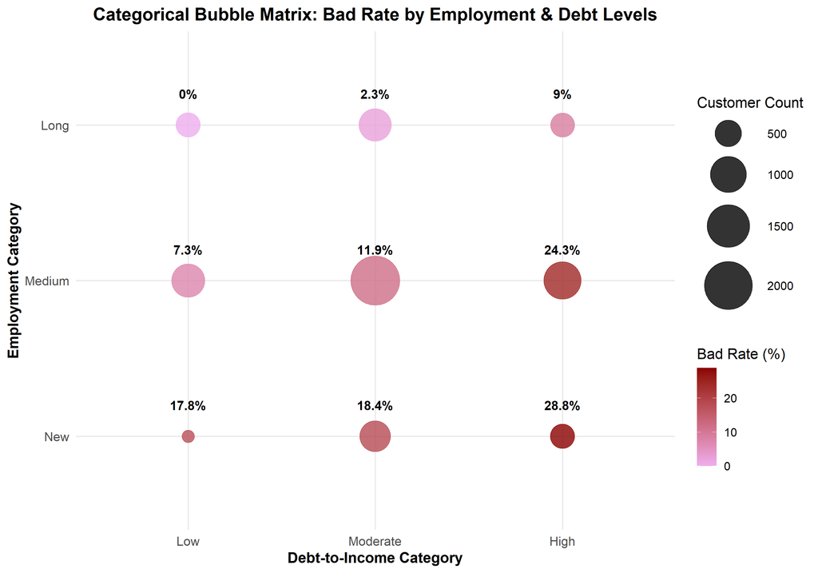

```r
# Create summary table for bubble matrix
bubble_data <- master_data %>%
  group_by(emp_cat, debtinc_cat) %>%
  summarise(
    Total = n(),
    Defaulters = sum(bad == 1),
    Bad_Rate = round((Defaulters / Total) * 100, 1),
    .groups = "drop"
  )

# Plot categorical bubble matrix
bubbleplot <- ggplot(bubble_data, aes(x = debtinc_cat, y = emp_cat)) +
  geom_point(aes(size = Total, color = Bad_Rate), alpha = 0.8) +
  geom_text(aes(label = paste0(Bad_Rate, "%"), y = as.numeric(emp_cat) + 0.2),
    fontface = "bold",
    size = 4,
    color = "black") +
  scale_size_continuous(range = c(5, 20), name = "Customer Count") +
  scale_color_gradient(low = "plum2", high = "darkred", name = "Bad Rate (%)") +
  labs(
    title = "Categorical Bubble Matrix: Bad Rate by Employment & Debt Levels",
    x = "Debt-to-Income Category", y = "Employment Category"
  ) +
  theme_minimal(base_size = 13) +
  theme(
    plot.title = element_text(hjust = 0.5, face = "bold"),
    axis.title = element_text(face = "bold"),
    axis.text = element_text(size = 11),
    legend.position = "right"
  )

bubbleplot
```

- The plot reveals that customers who are new employees and with high debt-to-income levels face the highest risk, with a bad rate of 28.8%.
- On the other hand, those with long employment and low/moderate debt show near-zero default rates, marking them as the safest group.
- The bubble size highlights that most customers fall into medium employment + moderate debt, a segment with moderate risk (11.9%).
- This matrix makes it easy to spot which customer groups are riskier and which are safer, helping guide smarter decisions in credit strategy and model building.
- A ridgeline plot to visualize how credit card debt varies across age groups, and how it links to bad rates by giving a clear view of age-wise financial risk.

**Ridgeline Plot**

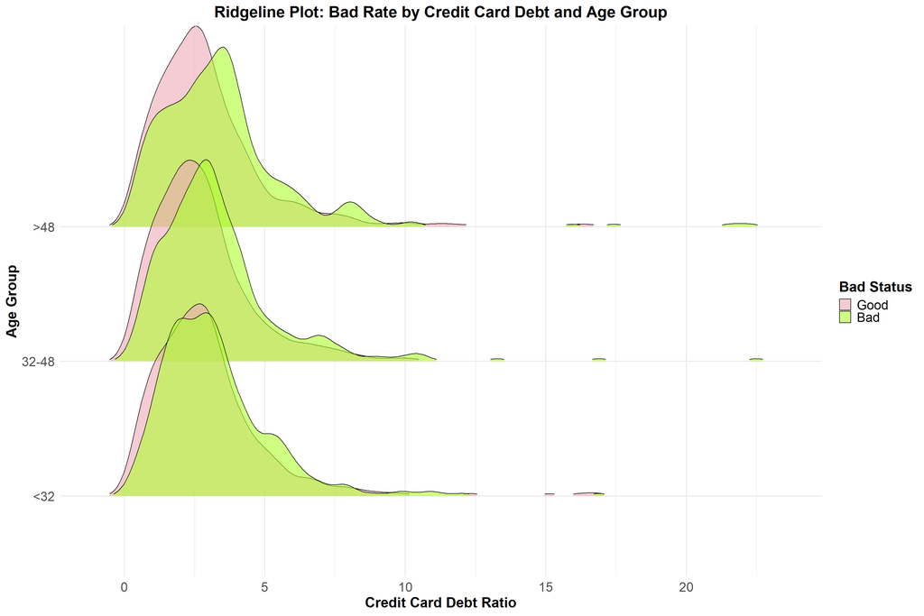

```r
ridgeline_plot <- ggplot(master_data, aes(x = creddebt, y = age, fill = as.factor(bad))) +
  geom_density_ridges(alpha = 0.6, scale = 1.5, rel_min_height = 0.01) +
  scale_fill_manual(values = c("0" = "pink2", "1" = "greenyellow"),
                    labels = c("Good", "Bad"),
                    name = "Bad Status") +
  labs(
    title = "Ridgeline Plot: Bad Rate by Credit Card Debt and Age Group",
    x = "Credit Card Debt Ratio", y = "Age Group"
  ) +
  theme_minimal(base_size = 16) +
  theme(
    plot.title = element_text(hjust = 0.5, face = "bold", size = 22),
    axis.title.x = element_text(size = 20, face = "bold"),
    axis.title.y = element_text(size = 20, face = "bold"),
    axis.text.x = element_text(size = 18),
    axis.text.y = element_text(size = 18),
    legend.title = element_text(face = "bold", size = 20),
    legend.text = element_text(size = 18)
  )

ridgeline_plot
```

Phase 3: Binary Logistic Regression Model

MODEL VERSION 1 (Using original numeric versions of emp, address, debtinc, creddebt, othdebt)

1. Create data partition into train and test data sets ( 80/20)

```r
# Importing libraries
library(caret)
library(car)
library(ROCR)

# Create data partition
set.seed(123)

train_index <- createDataPartition(master_data$bad, p = 0.8, list = FALSE)
train_data <- master_data[train_index, ]
test_data <- master_data[-train_index, ]
```

2. Run Binary Logistic Regression with “bad” as dependent variable and all others as independent variables (credit details, customer info, profile) on train data.

```r
model_logit <- glm(bad ~ . - custid - emp_cat - address_cat - debtinc_cat - creddebt_cat - othdebt_cat,
                   data = train_data, family = binomial)

summary(model_logit)
```

```
##
## Call:
## glm(formula = bad ~ . - custid - emp_cat - address_cat - debtinc_cat -
##     creddebt_cat - othdebt_cat, family = binomial, data = train_data)
##
## Coefficients:
##                          Estimate Std. Error z value Pr(>|z|)
## (Intercept)             -2.520704   0.319128  -7.899 2.82e-15 ***
## vehOwn Vehicle           0.055334   0.083913   0.659 0.509623
## houseOwn House           0.088590   0.083979   1.055 0.291469
## selfempSelf Employed     0.018788   0.083811   0.224 0.822621
## accountSame Bank (CASA)  0.139055   0.083861   1.658 0.097286 .
## depositHas Deposit       0.054702   0.083832   0.653 0.514064
## emp                     -0.145552   0.009809 -14.839  < 2e-16 ***
## address                 -0.027406   0.007279  -3.765 0.000167 ***
## branchNearest Branch    -0.266687   0.084404  -3.160 0.001580 **
## refInternal Reference   -0.105167   0.083806  -1.255 0.209519
## debtinc                  0.035408   0.006920   5.117 3.11e-07 ***
## creddebt                 0.185450   0.023462   7.904 2.70e-15 ***
## othdebt                  0.004279   0.017576   0.243 0.807654
## preloanNot First Loan    0.015125   0.083998   0.180 0.857103
## age32-48                -0.164511   0.102362  -1.607 0.108022
## age>48                   0.015981   0.101763   0.157 0.875216
## genderMale               0.034296   0.083870   0.409 0.682598
## msMarried               -0.125143   0.104230  -1.201 0.229889
## childMore than One      -0.008085   0.121002  -0.067 0.946725
## zone2                    1.636971   0.296301   5.525 3.30e-08 ***
## zone3                    1.069621   0.308426   3.468 0.000524 ***
## zone4                    0.283258   0.347537   0.815 0.415047
## zone5                    0.869507   0.320270   2.715 0.006629 **
## zone6                    1.026027   0.315041   3.257 0.001127 **
## zone7                    1.197283   0.310884   3.851 0.000118 ***
## zone8                    0.679371   0.324104   2.096 0.036069 *
## zone9                    1.233946   0.315394   3.912 9.14e-05 ***
## zone10                   0.491404   0.336406   1.461 0.144085
## zone11                   0.775302   0.321007   2.415 0.015726 *
## zone12                   1.025942   0.315470   3.252 0.001146 **
## zone13                   0.775734   0.317410   2.444 0.014527 *
## zone14                   0.480672   0.329463   1.459 0.144577
## zone15                   0.859017   0.328557   2.615 0.008935 **
## zone16                   0.608534   0.330694   1.840 0.065743 .
## zone17                   0.927105   0.316118   2.933 0.003359 **
## zone18                   1.173177   0.307725   3.812 0.000138 ***
## zone19                   0.639242   0.330204   1.936 0.052880 .
## zone20                   0.772256   0.326239   2.367 0.017926 *
## ---
## Signif. codes:  0 '***' 0.001 '**' 0.01 '*' 0.05 '.' 0.1 ' ' 1
##
## (Dispersion parameter for binomial family taken to be 1)
##
##     Null deviance: 4370.1  on 5589  degrees of freedom
## Residual deviance: 3808.7  on 5552  degrees of freedom
## AIC: 3884.7
##
## Number of Fisher Scoring iterations: 6
```

3. Check which variables are significant (revise the model if needed)
- The model identifies customer employment and address durations, branch types and debt-related variables (debtinc, creddebt) as statistically significant predictors of default probability.
- Additionally, several geographic zones (Zones 2,3,7,9,18) show strong influence, indicating regional patterns in customer credit risk.
- Variables like gender, marital status, vehicle or house ownership, and self-employment status did not show significant contribution to the model.

```r
# Revised logistic regression model (Model Version 1) using only significant numeric variables

model_logit_revised <- glm(bad ~ emp + address + branch + debtinc + creddebt + zone,
                           data = train_data, family = binomial)

summary(model_logit_revised)
```

```
##
## Call:
## glm(formula = bad ~ emp + address + branch + debtinc + creddebt +
##     zone, family = binomial, data = train_data)
##
## Coefficients:
##                       Estimate Std. Error z value Pr(>|z|)
## (Intercept)          -2.478822   0.280404  -8.840  < 2e-16 ***
## emp                  -0.144226   0.009522 -15.146  < 2e-16 ***
## address              -0.027002   0.007205  -3.748 0.000179 ***
## branchNearest Branch -0.268789   0.084155  -3.194 0.001403 **
## debtinc               0.036856   0.006273   5.876 4.21e-09 ***
## creddebt              0.185775   0.021724   8.551  < 2e-16 ***
## zone2                 1.626332   0.294599   5.520 3.38e-08 ***
## zone3                 1.051297   0.307287   3.421 0.000623 ***
## zone4                 0.282251   0.346026   0.816 0.414676
## zone5                 0.834347   0.318740   2.618 0.008854 **
## zone6                 1.008445   0.313547   3.216 0.001299 **
## zone7                 1.180097   0.309520   3.813 0.000137 ***
## zone8                 0.653392   0.322679   2.025 0.042878 *
## zone9                 1.215759   0.313945   3.873 0.000108 ***
## zone10                0.492811   0.335573   1.469 0.141951
## zone11                0.752211   0.319612   2.354 0.018597 *
## zone12                0.999847   0.313988   3.184 0.001451 **
## zone13                0.771756   0.316150   2.441 0.014642 *
## zone14                0.465999   0.328265   1.420 0.155730
## zone15                0.846351   0.327176   2.587 0.009686 **
## zone16                0.584903   0.329317   1.776 0.075715 .
## zone17                0.894285   0.314436   2.844 0.004454 **
## zone18                1.160176   0.306417   3.786 0.000153 ***
## zone19                0.635501   0.328839   1.933 0.053290 .
## zone20                0.768799   0.324763   2.367 0.017920 *
## ---
## Signif. codes:  0 '***' 0.001 '**' 0.01 '*' 0.05 '.' 0.1 ' ' 1
##
## (Dispersion parameter for binomial family taken to be 1)
##
##     Null deviance: 4370.1  on 5589  degrees of freedom
## Residual deviance: 3821.6  on 5565  degrees of freedom
## AIC: 3871.6
##
## Number of Fisher Scoring iterations: 6
```

4. Relate results to EDA (do not perform any new analysis)
- Zones such as Zone 2,3 and 18, which had higher bad rates in EDA, were also found highly significant in the model.
- Higher debt to income and higher credit card debt levels, which showed risk in EDA, were strongly significant predictors in the model.
- Although EDA showed slightly higher bad rates for owning a house, house ownership was not significant in the model.
- Similarly, demographic factors like age and gender had mild differences in bad rates during EDA but were not important in the model.
5. Check multicollinearity (use VIF)

```r
vif(model_logit_revised)
```

```
##              GVIF Df GVIF^(1/(2*Df))
## emp      1.388298  1        1.178261
## address  1.089441  1        1.043763
## branch   1.007383  1        1.003685
## debtinc  1.316149  1        1.147236
## creddebt 1.758673  1        1.326150
## zone     1.031888 19        1.000826
```

- All GVIF values are below 5, indicating no multicollinearity among the predictors.
- This confirms that the variables in the revised model are independently contributing to the prediction of default.
6. Obtain ROC curve and AUC for train data

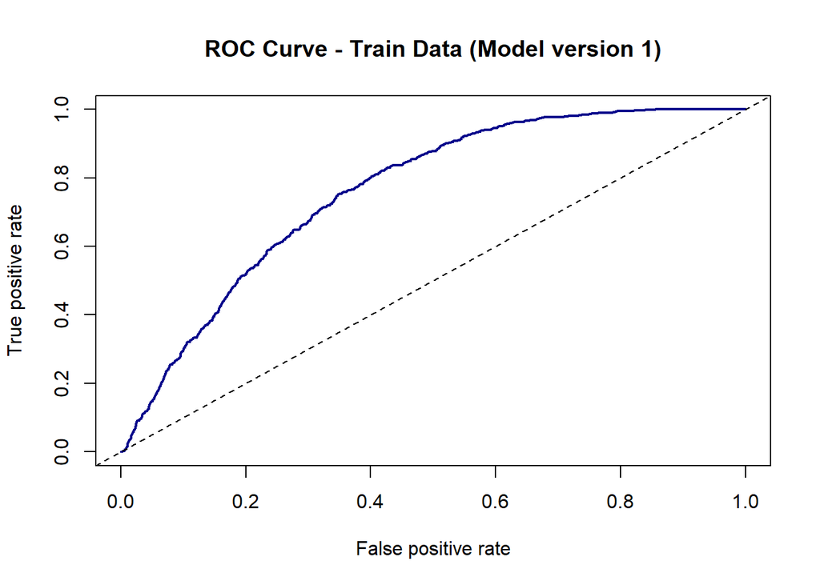

```r
train_pred_prob <- predict(model_logit_revised, newdata = train_data, type = "response")
pred_train <- prediction(train_pred_prob, train_data$bad)
perf_roc <- performance(pred_train, "tpr", "fpr")
plot(perf_roc, main = "ROC Curve - Train Data (Model version 1)", col = "darkblue", lwd = 2)
abline(0, 1, lty = 2, col = "black")
```

- The ROC curve for the train data shows good model performance, with the curve rising well above the diagonal line, indicating effective separation between defaulters and non-defaulters.

```r
# Compute AUC
auc_train <- performance(pred_train, "auc")
auc_value <- auc_train@y.values[[1]]
cat("AUC (Train Data - Model V1):", round(auc_value, 4), "\n")
```

```
## AUC (Train Data - Model V1): 0.7617
```

- The AUC value of 0.7617 confirms that the model has a 76.2% ability to distinguish between defaulters and non-defaulters across all thresholds on the training data.
7. Obtain classification table and accuracy (%)

```r
threshold <- 0.5

# Predicted Y for train data
train_data$predY <- as.factor(ifelse(train_pred_prob > threshold, 1, 0))

#Train data confusion Matrix
confusionMatrix(train_data$predY, as.factor(train_data$bad),positive="1")
```

```
## Confusion Matrix and Statistics
##
##           Reference
## Prediction    0    1
##          0 4806  730
##          1   44   10
##
##                Accuracy : 0.8615
##                  95% CI : (0.8522, 0.8705)
##     No Information Rate : 0.8676
##     P-Value [Acc > NIR] : 0.9127
##
##                   Kappa : 0.0073
##
##  Mcnemar's Test P-Value : <2e-16
##
##             Sensitivity : 0.013514
##             Specificity : 0.990928
##          Pos Pred Value : 0.185185
##          Neg Pred Value : 0.868136
##              Prevalence : 0.132379
##          Detection Rate : 0.001789
##    Detection Prevalence : 0.009660
##       Balanced Accuracy : 0.502221
##
##        'Positive' Class : 1
##
```

- The model achieved an overall accuracy of 86.15% on the training data.
- However, its sensitivity is very low (1.35%), meaning it is missing most of the actual defaulters while correctly identifying non-defaulters.
8. Obtain threshold to balance sensitivity and specificity

```r
# Performance for sensitivity and specificity
perf <- performance(pred_train, "sens", "spec")

sensitivity <- perf@y.values[[1]]
specificity <- perf@x.values[[1]]
thresholds <- perf@alpha.values[[1]]

# Find the threshold where sensitivity and specificity are closest
diff <- abs(sensitivity - specificity)
best_index <- which.min(diff)

best_threshold <- thresholds[best_index]
cat("Optimal Threshold (Balanced Sensitivity & Specificity - Model V1):", round(best_threshold, 3), "\n")
```

```
## Optimal Threshold (Balanced Sensitivity & Specificity - Model V1): 0.147
```

- The optimal cutoff threshold was found as 0.147, which balances sensitivity and specificity on the training data.

```r
threshold <- 0.147

train_data$predY <- as.factor(ifelse(train_pred_prob > threshold, 1, 0))
confusionMatrix(train_data$predY, as.factor(train_data$bad),positive="1")
```

```
## Confusion Matrix and Statistics
##
##           Reference
## Prediction    0    1
##          0 3353  228
##          1 1497  512
##
##                Accuracy : 0.6914
##                  95% CI : (0.6791, 0.7035)
##     No Information Rate : 0.8676
##     P-Value [Acc > NIR] : 1
##
##                   Kappa : 0.222
##
##  Mcnemar's Test P-Value : <2e-16
##
##             Sensitivity : 0.69189
##             Specificity : 0.69134
##          Pos Pred Value : 0.25485
##          Neg Pred Value : 0.93633
##              Prevalence : 0.13238
##          Detection Rate : 0.09159
##    Detection Prevalence : 0.35939
##       Balanced Accuracy : 0.69162
##
##        'Positive' Class : 1
##
```

- The model achieved accuracy of 69.1%, with both sensitivity (69.2%) and specificity (69.1%) at nearly equal levels.
- This balance indicates that the model can reliably detect defaulters (sensitivity) while still maintaining a good rate of correctly identifying non-defaulters (specificity).
- Although the overall accuracy decreased to 69.1%, this trade-off is acceptable in credit scoring where identifying potential risk is more important than overall correctness.
9. Obtain ROC curve and AUC for test data (compare with step 6)

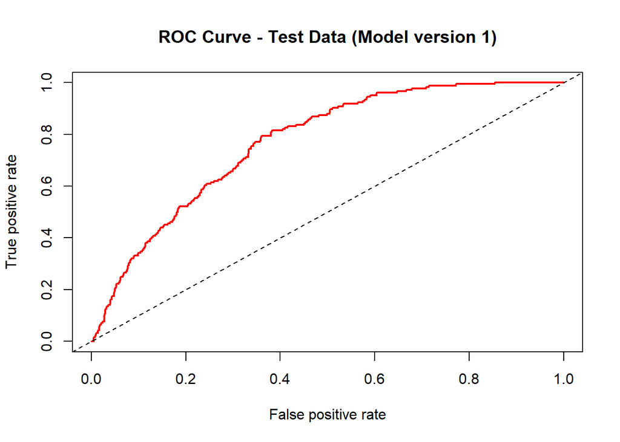

```r
test_pred_prob <- predict(model_logit_revised, newdata = test_data, type = "response")
pred_test <- prediction(test_pred_prob, test_data$bad)
perf_test <- performance(pred_test, "tpr", "fpr")
plot(perf_test, main = "ROC Curve - Test Data (Model version 1)", col = "red", lwd = 2)
abline(0, 1, lty = 2, col = "black")
```

- The ROC curve for the test data shows strong separation between classes, indicating the model’s ability to effectively distinguish defaulters from non-defaulters.

```r
auc_test <- performance(pred_test, "auc")
auc_test_value <- auc_test@y.values[[1]]
cat("AUC (Test Data - Model V1):", round(auc_test_value, 4), "\n")
```

```
## AUC (Test Data - Model V1): 0.77
```

- The model achieved an AUC of 0.77 on the test data and 0.7617 on the training data, indicating consistent predictive performance.
- The slightly higher AUC on the test data suggests that the model generalizes well and is not overfitted, making it reliable for real-world credit risk classification.
10. Use above threshold to obtain accuracy, sensitivity and specificity for test data (compare with step 7)

```r
threshold <- 0.147

test_pred_prob <- predict(model_logit_revised, newdata = test_data, type = "response")
test_data$predY <- as.factor(ifelse(test_pred_prob > threshold, 1, 0))
confusionMatrix(test_data$predY, as.factor(test_data$bad), positive = "1")
```

```
## Confusion Matrix and Statistics
##
##           Reference
## Prediction   0   1
##          0 837  59
##          1 375 125
##
##                Accuracy : 0.6891
##                  95% CI : (0.6641, 0.7133)
##     No Information Rate : 0.8682
##     P-Value [Acc > NIR] : 1
##
##                   Kappa : 0.214
##
##  Mcnemar's Test P-Value : <2e-16
##
##             Sensitivity : 0.67935
##             Specificity : 0.69059
##          Pos Pred Value : 0.25000
##          Neg Pred Value : 0.93415
##              Prevalence : 0.13181
##          Detection Rate : 0.08954
##    Detection Prevalence : 0.35817
##       Balanced Accuracy : 0.68497
##
##        'Positive' Class : 1
##
```

- The model version 1 achieved accuracy of 68.9%, with sensitivity at 67.9% and specificity at 69.1%, when applying the optimized threshold of 0.147 to the test data.
- These results are highly consistent with the training performance, confirming the model’s stability and reliability in predicting credit default risk.
- Compared to Step 7 (default threshold of 0.5 on train data), the sensitivity improved significantly from 1.35% to 67.9%, while maintaining a good balance between accuracy and specificity.

MODEL VERSION 2 (Using categorical (recoded) versions of emp, address, debtinc, creddebt, othdebt)

2. Run Binary Logistic Regression with “bad” as dependent variable and all others as independent variables on train data.

```r
# Removing the predY column
train_data <- train_data %>% select(-predY)
test_data <- test_data %>% select(-predY)

# Building the model
model_logit2 <- glm(bad ~ . - custid - emp - address - debtinc - creddebt - othdebt,
                    data = train_data, family = binomial)

summary(model_logit2)
```

```
##
## Call:
## glm(formula = bad ~ . - custid - emp - address - debtinc - creddebt -
##     othdebt, family = binomial, data = train_data)
##
## Coefficients:
##                         Estimate Std. Error z value Pr(>|z|)
## (Intercept)             -2.93519    0.33971  -8.640  < 2e-16 ***
## vehOwn Vehicle           0.05780    0.08298   0.697 0.486065
## houseOwn House           0.10517    0.08302   1.267 0.205231
## selfempSelf Employed     0.04215    0.08298   0.508 0.611530
## accountSame Bank (CASA)  0.12444    0.08298   1.500 0.133704
## depositHas Deposit       0.04076    0.08303   0.491 0.623496
## branchNearest Branch    -0.24976    0.08365  -2.986 0.002827 **
## refInternal Reference   -0.08230    0.08304  -0.991 0.321652
## preloanNot First Loan    0.02497    0.08308   0.301 0.763763
## age32-48                -0.14864    0.10149  -1.465 0.143018
## age>48                   0.05309    0.10064   0.528 0.597814
## genderMale               0.03538    0.08293   0.427 0.669644
## msMarried               -0.07870    0.10309  -0.763 0.445219
## childMore than One      -0.02725    0.11982  -0.227 0.820116
## zone2                    1.60266    0.29358   5.459 4.79e-08 ***
## zone3                    1.14312    0.30549   3.742 0.000183 ***
## zone4                    0.28111    0.34394   0.817 0.413742
## zone5                    0.86800    0.31771   2.732 0.006294 **
## zone6                    0.99997    0.31227   3.202 0.001364 **
## zone7                    1.14589    0.30835   3.716 0.000202 ***
## zone8                    0.65347    0.32146   2.033 0.042069 *
## zone9                    1.15543    0.31163   3.708 0.000209 ***
## zone10                   0.57022    0.33207   1.717 0.085949 .
## zone11                   0.74348    0.31852   2.334 0.019586 *
## zone12                   1.00477    0.31267   3.214 0.001311 **
## zone13                   0.80910    0.31421   2.575 0.010022 *
## zone14                   0.48574    0.32643   1.488 0.136733
## zone15                   0.85082    0.32535   2.615 0.008920 **
## zone16                   0.55107    0.32779   1.681 0.092728 .
## zone17                   0.91150    0.31310   2.911 0.003600 **
## zone18                   1.18044    0.30476   3.873 0.000107 ***
## zone19                   0.57616    0.32719   1.761 0.078250 .
## zone20                   0.77854    0.32418   2.402 0.016325 *
## emp_catMedium           -0.49375    0.09707  -5.087 3.65e-07 ***
## emp_catLong             -1.96741    0.18348 -10.723  < 2e-16 ***
## address_catMedium        0.16751    0.10799   1.551 0.120863
## address_catLong         -0.35246    0.14792  -2.383 0.017186 *
## debtinc_catModerate      0.54696    0.14215   3.848 0.000119 ***
## debtinc_catHigh          1.29271    0.16409   7.878 3.33e-15 ***
## creddebt_catModerate     0.11030    0.10072   1.095 0.273466
## creddebt_catHigh         0.46488    0.13403   3.468 0.000524 ***
## othdebt_catModerate     -0.18642    0.11618  -1.605 0.108593
## othdebt_catHigh         -0.14447    0.15763  -0.916 0.359416
## ---
## Signif. codes:  0 '***' 0.001 '**' 0.01 '*' 0.05 '.' 0.1 ' ' 1
##
## (Dispersion parameter for binomial family taken to be 1)
##
##     Null deviance: 4370.1  on 5589  degrees of freedom
## Residual deviance: 3900.6  on 5547  degrees of freedom
## AIC: 3986.6
##
## Number of Fisher Scoring iterations: 6
```

- The logistic regression model identified branch, specific zones, employment and address duration, debt and credit levels as significant predictors of credit default risk.
3. Check which variables are significant (revise the model if needed)

```r
model_logit2_revised <- glm(bad ~ branch + zone + emp_cat + address_cat + debtinc_cat + creddebt_cat,
                            data = train_data, family = binomial)

summary(model_logit2_revised)
```

```
##
## Call:
## glm(formula = bad ~ branch + zone + emp_cat + address_cat + debtinc_cat +
##     creddebt_cat, family = binomial, data = train_data)
##
## Coefficients:
##                      Estimate Std. Error z value Pr(>|z|)
## (Intercept)          -2.89153    0.30258  -9.556  < 2e-16 ***
## branchNearest Branch -0.25156    0.08336  -3.018 0.002546 **
## zone2                 1.60505    0.29224   5.492 3.97e-08 ***
## zone3                 1.14437    0.30445   3.759 0.000171 ***
## zone4                 0.27652    0.34283   0.807 0.419916
## zone5                 0.84366    0.31646   2.666 0.007678 **
## zone6                 0.99871    0.31106   3.211 0.001324 **
## zone7                 1.14265    0.30726   3.719 0.000200 ***
## zone8                 0.64095    0.32029   2.001 0.045371 *
## zone9                 1.14561    0.31045   3.690 0.000224 ***
## zone10                0.58438    0.33114   1.765 0.077609 .
## zone11                0.72923    0.31742   2.297 0.021598 *
## zone12                0.98906    0.31140   3.176 0.001492 **
## zone13                0.80319    0.31320   2.564 0.010334 *
## zone14                0.48196    0.32543   1.481 0.138608
## zone15                0.83656    0.32425   2.580 0.009879 **
## zone16                0.54296    0.32661   1.662 0.096431 .
## zone17                0.88716    0.31173   2.846 0.004428 **
## zone18                1.17562    0.30363   3.872 0.000108 ***
## zone19                0.58246    0.32605   1.786 0.074028 .
## zone20                0.77486    0.32318   2.398 0.016503 *
## emp_catMedium        -0.49180    0.09510  -5.171 2.33e-07 ***
## emp_catLong          -1.97519    0.17701 -11.159  < 2e-16 ***
## address_catMedium     0.15493    0.10696   1.448 0.147493
## address_catLong      -0.37133    0.14615  -2.541 0.011062 *
## debtinc_catModerate   0.48140    0.13532   3.558 0.000374 ***
## debtinc_catHigh       1.20918    0.14532   8.321  < 2e-16 ***
## creddebt_catModerate  0.10777    0.10028   1.075 0.282473
## creddebt_catHigh      0.47593    0.12997   3.662 0.000250 ***
## ---
## Signif. codes:  0 '***' 0.001 '**' 0.01 '*' 0.05 '.' 0.1 ' ' 1
##
## (Dispersion parameter for binomial family taken to be 1)
##
##     Null deviance: 4370.1  on 5589  degrees of freedom
## Residual deviance: 3914.8  on 5561  degrees of freedom
## AIC: 3972.8
##
## Number of Fisher Scoring iterations: 6
```

4. Relate results to EDA (do not perform any new analysis)
- Customers from zones 2, 3, 7, 9, and 18, showed strong significance, confirming the EDA findings.
- Employment category and debt to income category results also aligned well. Long employment tenure showed much lower default risk as seen in EDA.
- The address category “Medium” showed slightly high bad rates in EDA but was not strongly significant in the model.
- House ownership and reference type status showed noticeable bad rates in EDA but did not show significant contribution to the model.
5. Check multicollinearity (use VIF)

```r
vif(model_logit2_revised)
```

```
##                  GVIF Df GVIF^(1/(2*Df))
## branch       1.009438  1        1.004708
## zone         1.048187 19        1.001239
## emp_cat      1.126366  2        1.030196
## address_cat  1.077197  2        1.018764
## debtinc_cat  1.260958  2        1.059681
## creddebt_cat 1.355506  2        1.079010
```

- All GVIF values are less than 5, indicating no signs of multicollinearity among the predictors in the revised model.
6. Obtain ROC curve and AUC for train data

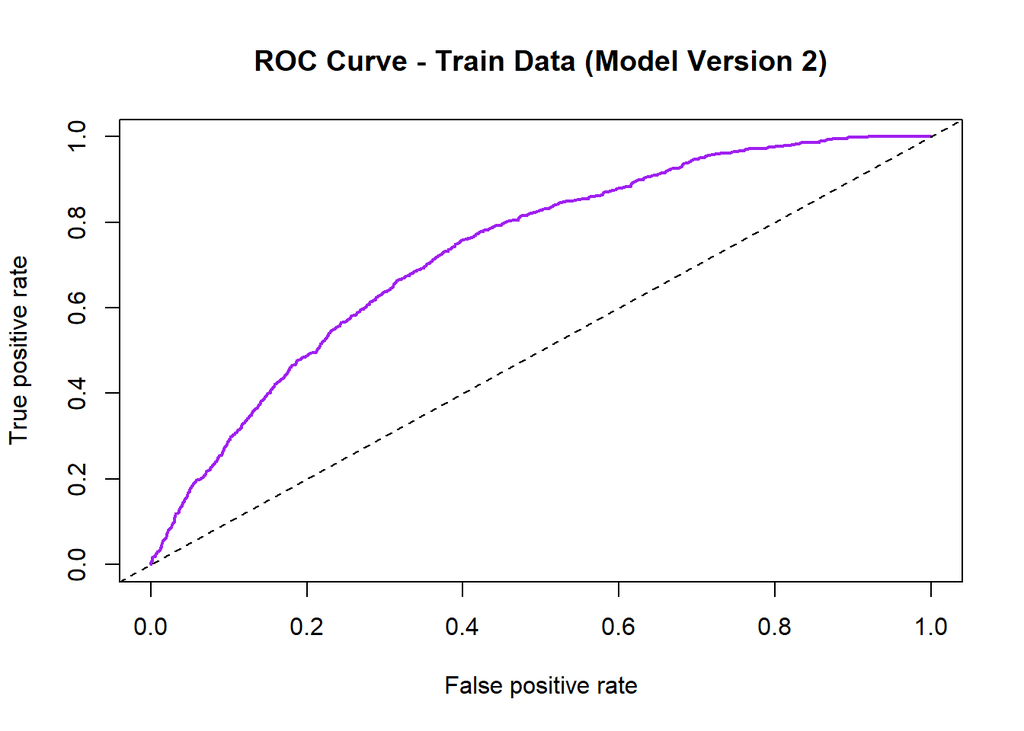

```r
# ROC curve
train_pred_prob2 <- predict(model_logit2_revised, newdata = train_data, type = "response")

pred_train2 <- prediction(train_pred_prob2, train_data$bad)
perf_roc2 <- performance(pred_train2, "tpr", "fpr")
plot(perf_roc2, main = "ROC Curve - Train Data (Model Version 2)", col = "purple", lwd = 2)
abline(0, 1, lty = 2, col = "black")
```

- The ROC curve for Model Version 2 on the train data shows good separation between defaulters and non-defaulters, indicating reasonable model performance.

```r
# Calculate AUC
auc_train2 <- performance(pred_train2, "auc")
auc_value2 <- auc_train2@y.values[[1]]
cat("AUC (Train Data - Model V2):", round(auc_value2, 4), "\n")
```

```
## AUC (Train Data - Model V2): 0.7335
```

- The AUC of 0.7335 indicates the model has a 73.4% probability of correctly distinguishing between a bad and good customer based on training data.
7. Obtain classification table and accuracy (%)

```r
threshold2 <- 0.5

train_data$predY2 <- as.factor(ifelse(train_pred_prob2 > threshold2, 1, 0))
confusionMatrix(train_data$predY2, as.factor(train_data$bad), positive = "1")
```

```
## Confusion Matrix and Statistics
##
##           Reference
## Prediction    0    1
##          0 4838  727
##          1   12   13
##
##                Accuracy : 0.8678
##                  95% CI : (0.8586, 0.8766)
##     No Information Rate : 0.8676
##     P-Value [Acc > NIR] : 0.4941
##
##                   Kappa : 0.0256
##
##  Mcnemar's Test P-Value : <2e-16
##
##             Sensitivity : 0.017568
##             Specificity : 0.997526
##          Pos Pred Value : 0.520000
##          Neg Pred Value : 0.869362
##              Prevalence : 0.132379
##          Detection Rate : 0.002326
##    Detection Prevalence : 0.004472
##       Balanced Accuracy : 0.507547
##
##        'Positive' Class : 1
##
```

- At the default threshold of 0.5, the model achieved an overall accuracy of 86.8%, driven mainly by correctly classifying non-defaulters.
- However, with a sensitivity of only 1.76%, the model fails to detect most defaulters, indicating the need for a better threshold.
8. Obtain threshold to balance sensitivity and specificity

```r
pred_train2 <- prediction(train_pred_prob2, train_data$bad)
perf2 <- performance(pred_train2, "sens", "spec")

sensitivity2 <- perf2@y.values[[1]]
specificity2 <- perf2@x.values[[1]]
thresholds2 <- perf2@alpha.values[[1]]

# Find the threshold where sensitivity and specificity are closest
diff2 <- abs(sensitivity2 - specificity2)
best_index2 <- which.min(diff2)

best_threshold2 <- thresholds2[best_index2]
cat("Optimal Threshold (Balanced Sensitivity & Specificity - Model V2):", round(best_threshold2, 3), "\n")
```

```
## Optimal Threshold (Balanced Sensitivity & Specificity - Model V2): 0.139
```

- The optimal threshold for balancing sensitivity and specificity in Model Version 2 is 0.139.

```r
threshold2 <- 0.139

train_data$predY2 <- as.factor(ifelse(train_pred_prob2 > threshold2, 1, 0))
confusionMatrix(train_data$predY2, as.factor(train_data$bad),positive="1")
```

```
## Confusion Matrix and Statistics
##
##           Reference
## Prediction    0    1
##          0 3262  241
##          1 1588  499
##
##                Accuracy : 0.6728
##                  95% CI : (0.6603, 0.6851)
##     No Information Rate : 0.8676
##     P-Value [Acc > NIR] : 1
##
##                   Kappa : 0.1958
##
##  Mcnemar's Test P-Value : <2e-16
##
##             Sensitivity : 0.67432
##             Specificity : 0.67258
##          Pos Pred Value : 0.23910
##          Neg Pred Value : 0.93120
##              Prevalence : 0.13238
##          Detection Rate : 0.08927
##    Detection Prevalence : 0.37335
##       Balanced Accuracy : 0.67345
##
##        'Positive' Class : 1
##
```

- At the optimal threshold of 0.139, Model Version 2 achieved accuracy of 67.3%, with sensitivity around 67.4% and specificity around 67.3%.
- This represents a significant improvement in detecting defaulters compared to the default threshold, making the model more suitable for credit risk classification.
9. Obtain ROC curve and AUC for test data (compare with step 6)

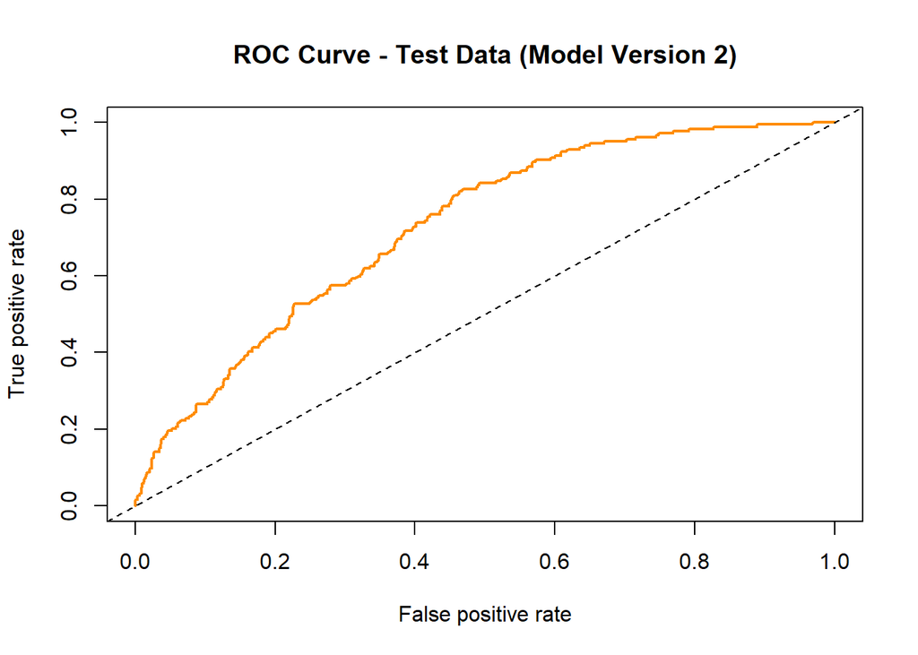

```r
test_pred_prob2 <- predict(model_logit2_revised, newdata = test_data, type = "response")
pred_test2 <- prediction(test_pred_prob2, test_data$bad)

perf_test2 <- performance(pred_test2, "tpr", "fpr")
plot(perf_test2, main = "ROC Curve - Test Data (Model Version 2)", col = "darkorange", lwd = 2)
abline(0, 1, lty = 2, col = "black")
```

- The ROC curve for Model Version 2 on the test data rises steadily, showing that the model does a good job spotting who’s likely to default and who isn’t.

```r
# Calculate AUC
auc_test2 <- performance(pred_test2, "auc")
auc_test_value2 <- auc_test2@y.values[[1]]
cat("AUC (Test Data - Model V2):", round(auc_test_value2, 4), "\n")
```

```
## AUC (Test Data - Model V2): 0.7281
```

- Model Version 2 achieved an AUC of 0.7281 on test data and 0.7335 on training data, showing consistent predictive performance.
- The small difference indicates the model generalizes well without overfitting, making it reliable for identifying default risk on unseen data.
10. Use above threshold to obtain accuracy, sensitivity and specificity for test data (compare with step 7)

```r
threshold2 <- 0.139

test_data$predY2 <- as.factor(ifelse(test_pred_prob2 > threshold2, 1, 0))
confusionMatrix(test_data$predY2, as.factor(test_data$bad), positive = "1")
```

```
## Confusion Matrix and Statistics
##
##           Reference
## Prediction   0   1
##          0 817  71
##          1 395 113
##
##                Accuracy : 0.6662
##                  95% CI : (0.6408, 0.6909)
##     No Information Rate : 0.8682
##     P-Value [Acc > NIR] : 1
##
##                   Kappa : 0.165
##
##  Mcnemar's Test P-Value : <2e-16
##
##             Sensitivity : 0.61413
##             Specificity : 0.67409
##          Pos Pred Value : 0.22244
##          Neg Pred Value : 0.92005
##              Prevalence : 0.13181
##          Detection Rate : 0.08095
##    Detection Prevalence : 0.36390
##       Balanced Accuracy : 0.64411
##
##        'Positive' Class : 1
##
```

- After applying the optimal threshold of 0.139 to the test data, Model Version 2 achieved an accuracy of 66.6%, with a significant improvement in sensitivity (61.4%) compared to just 1.76% at the default threshold.

Finalize the model by comparing test data AUC

```r
model <- c("Model Version 1", "Model Version 2")
auc <- c(auc_test_value, auc_test_value2)

auc_table <- data.frame(Model = model, Test_AUC = auc)
auc_table$Test_AUC <- round(auc_table$Test_AUC, 4)
auc_table
```

```
##             Model Test_AUC
## 1 Model Version 1   0.7700
## 2 Model Version 2   0.7281
```

- Model Version 1 (model_logit_revised), with a test AUC of 77%, outperformed Model Version 2 (72.8%).
- This confirms that Model Version 1 is the stronger model for predicting credit default risk compared to Model Version 2.

Phase 4: ML Methods

Naive Bayes Method

Create data partition into train and test data sets (80/20)

```r
# Importing required library
library(e1071)

# Data partition already done for Logistic Regression

# Removing the predY2 and recoded variables
train_data <- train_data %>%
  select(-predY2, -custid, -emp_cat, -address_cat, -debtinc_cat, -creddebt_cat, -othdebt_cat)

test_data <- test_data %>%
  select(-predY2, -custid, -emp_cat, -address_cat, -debtinc_cat, -creddebt_cat, -othdebt_cat)
```

Apply Naive Bayes Method on train data (“bad” as dependent variables and all others as independent variables (credit details, customer info, profile) on train data.

```r
model_nb <- naiveBayes(bad ~ ., data = train_data)
```

Obtain ROC curve and AUC for train data

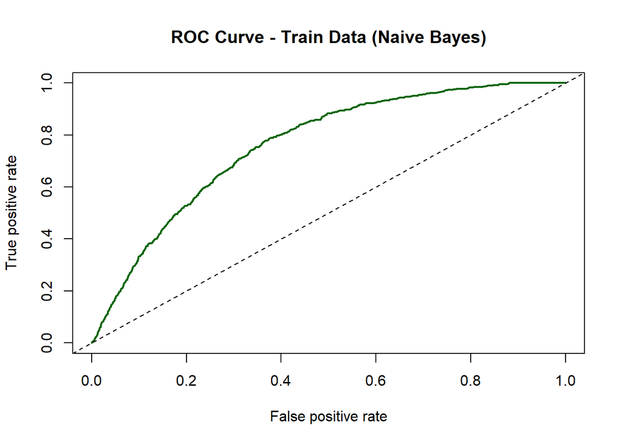

```r
# Predict probabilities for train data
train_pred_prob_nb <- predict(model_nb, train_data, type = "raw")[,2]

# Plot ROC curve
pred_train_nb <- prediction(train_pred_prob_nb, train_data$bad)
perf_train_nb <- performance(pred_train_nb, "tpr", "fpr")

plot(perf_train_nb, main = "ROC Curve - Train Data (Naive Bayes)", col = "darkgreen", lwd = 2)
abline(0, 1, lty = 2)
```

```r
# AUC value
auc_train_nb <- performance(pred_train_nb, "auc")
auc_train_value_nb <- auc_train_nb@y.values[[1]]
cat("AUC (Train Data - Naive Bayes):", round(auc_train_value_nb, 4), "\n")
```

```
## AUC (Train Data - Naive Bayes): 0.762
```

- The ROC curve shows a reasonably good separation with an AUC of 0.762, indicating that the Naive Bayes model has acceptable predictive ability on the train data.

Obtain Confusion Matrix for train data

```r
train_pred_class_nb <- predict(model_nb, train_data)
confusionMatrix(train_pred_class_nb, as.factor(train_data$bad), positive = "1")
```

```
## Confusion Matrix and Statistics
##
##           Reference
## Prediction    0    1
##          0 4757  693
##          1   93   47
##
##                Accuracy : 0.8594
##                  95% CI : (0.85, 0.8684)
##     No Information Rate : 0.8676
##     P-Value [Acc > NIR] : 0.9659
##
##                   Kappa : 0.0675
##
##  Mcnemar's Test P-Value : <2e-16
##
##             Sensitivity : 0.063514
##             Specificity : 0.980825
##          Pos Pred Value : 0.335714
##          Neg Pred Value : 0.872844
##              Prevalence : 0.132379
##          Detection Rate : 0.008408
##    Detection Prevalence : 0.025045
##       Balanced Accuracy : 0.522169
##
##        'Positive' Class : 1
##
```

- The Naive Bayes model achieved an accuracy of 85.94% on train data, with high specificity (98.08%) but low sensitivity (6.35%), indicating stronger identification of non-defaulters compared to defaulters.

Obtain ROC curve and AUC for test data

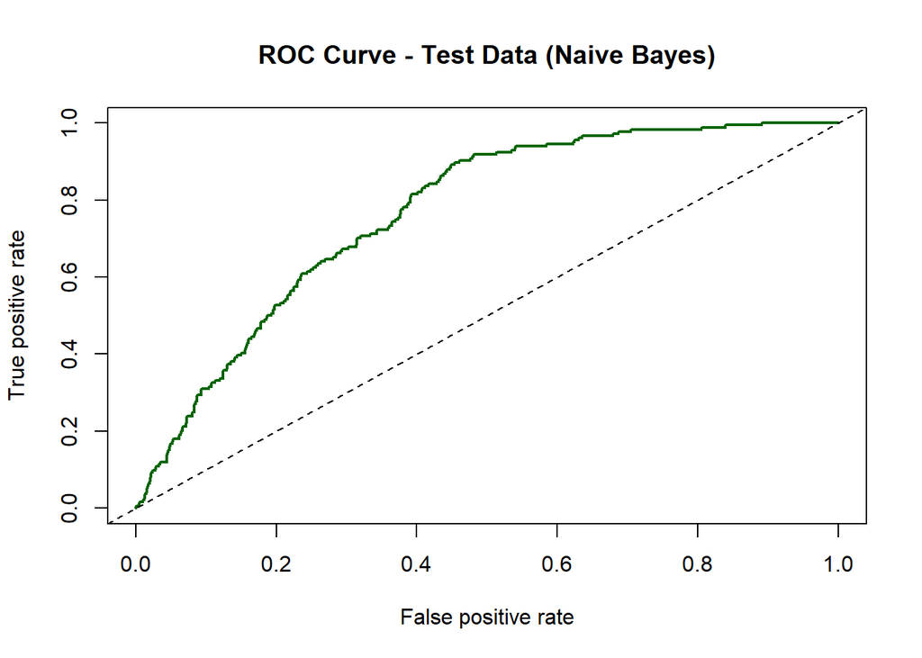

```r
# Predict probabilities for test data
test_pred_prob_nb <- predict(model_nb, test_data, type = "raw")[,2]

# Plot ROC curve
pred_test_nb <- prediction(test_pred_prob_nb, test_data$bad)
perf_test_nb <- performance(pred_test_nb, "tpr", "fpr")

plot(perf_test_nb, main = "ROC Curve - Test Data (Naive Bayes)", col = "darkgreen", lwd = 2)
abline(0, 1, lty = 2)
```

```r
# AUC value for test data
auc_test_nb <- performance(pred_test_nb, "auc")
auc_test_value_nb <- auc_test_nb@y.values[[1]]
cat("AUC (Test Data - Naive Bayes):", round(auc_test_value_nb, 4), "\n")
```

```
## AUC (Test Data - Naive Bayes): 0.7665
```

- The ROC curve for test data shows reasonable performance with an AUC of 0.7665, indicating good model discrimination between defaulters and non-defaulters.

Obtain Confusion Matrix for test data

```r
test_pred_class_nb <- predict(model_nb, test_data)
confusionMatrix(test_pred_class_nb, as.factor(test_data$bad), positive = "1")
```

```
## Confusion Matrix and Statistics
##
##           Reference
## Prediction    0    1
##          0 1188  172
##          1   24   12
##
##                Accuracy : 0.8596
##                  95% CI : (0.8403, 0.8774)
##     No Information Rate : 0.8682
##     P-Value [Acc > NIR] : 0.8388
##
##                   Kappa : 0.0689
##
##  Mcnemar's Test P-Value : <2e-16
##
##             Sensitivity : 0.065217
##             Specificity : 0.980198
##          Pos Pred Value : 0.333333
##          Neg Pred Value : 0.873529
##              Prevalence : 0.131805
##          Detection Rate : 0.008596
##    Detection Prevalence : 0.025788
##       Balanced Accuracy : 0.522708
##
##        'Positive' Class : 1
##
```

- On the test data, the Naive Bayes model achieved 85.96% accuracy, with high specificity (98.02%) but low sensitivity (6.52%).

Support Vector Machine (SVM) Method

Apply SVM Method on Train Data

```r
model_svm <- svm(bad ~ ., data = train_data, kernel = "linear", type = "C", probability = TRUE)
model_svm
```

```
##
## Call:
## svm(formula = bad ~ ., data = train_data, kernel = "linear", type = "C",
##     probability = TRUE)
##
##
## Parameters:
##    SVM-Type:  C-classification
##  SVM-Kernel:  linear
##        cost:  1
##
## Number of Support Vectors:  2101
```

- A linear kernel SVM model was built using C-classification with a cost of 1, utilizing 2101 support vectors to separate defaulters and non-defaulters.

Obtain ROC curve and AUC for train data

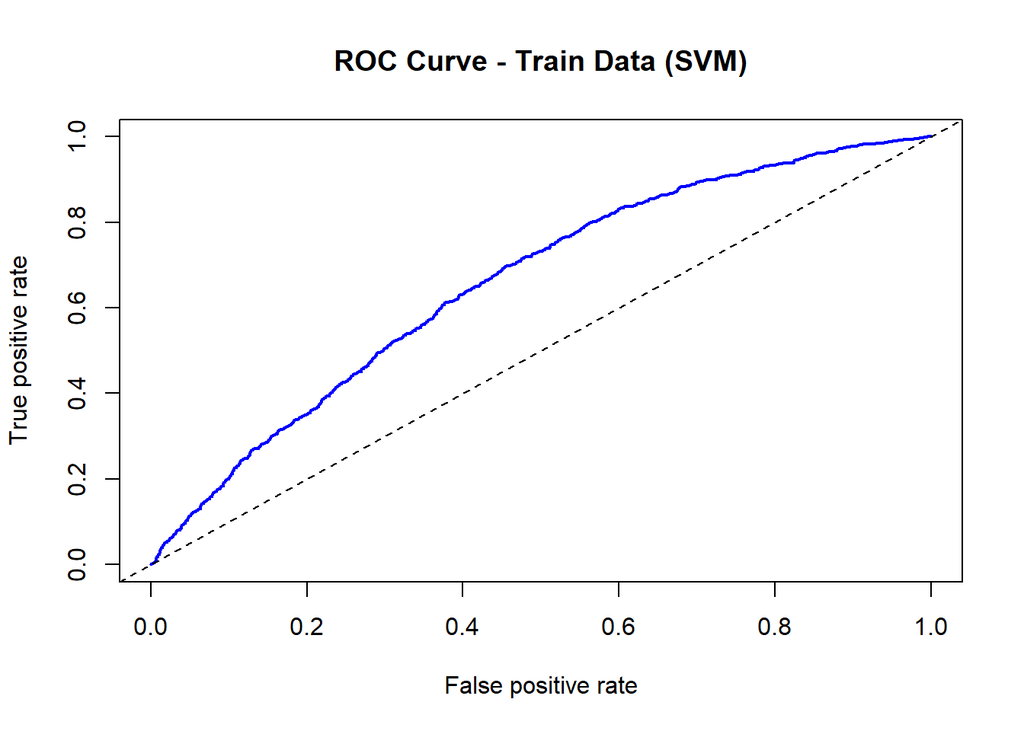

```r
# Predict probabilities for train data
train_pred_svm <- predict(model_svm, train_data, probability = TRUE)
train_pred_prob_svm <- attr(train_pred_svm, "probabilities")[, "1"]

# Plot ROC curve
pred_train_svm <- prediction(train_pred_prob_svm, train_data$bad)
perf_train_svm <- performance(pred_train_svm, "tpr", "fpr")

plot(perf_train_svm, main = "ROC Curve - Train Data (SVM)", col = "blue", lwd = 2)
abline(0, 1, lty = 2)
```

```r
# AUC value for train data
auc_train_svm <- performance(pred_train_svm, "auc")
auc_train_value_svm <- auc_train_svm@y.values[[1]]
cat("AUC (Train Data - SVM):", round(auc_train_value_svm, 4), "\n")
```

```
## AUC (Train Data - SVM): 0.6582
```

- The ROC curve for train data shows weak discriminatory ability with a low AUC of 0.6582, indicating that the SVM model struggles to separate defaulters from non-defaulters.

Obtain Confusion Matrix for train data

```r
train_pred_class_svm <- predict(model_svm, train_data)
confusionMatrix(train_pred_class_svm, as.factor(train_data$bad), positive = "1")
```

```
## Confusion Matrix and Statistics
##
##           Reference
## Prediction    0    1
##          0 4850  740
##          1    0    0
##
##                Accuracy : 0.8676
##                  95% CI : (0.8585, 0.8764)
##     No Information Rate : 0.8676
##     P-Value [Acc > NIR] : 0.5098
##
##                   Kappa : 0
##
##  Mcnemar's Test P-Value : <2e-16
##
##             Sensitivity : 0.0000
##             Specificity : 1.0000
##          Pos Pred Value :    NaN
##          Neg Pred Value : 0.8676
##              Prevalence : 0.1324
##          Detection Rate : 0.0000
##    Detection Prevalence : 0.0000
##       Balanced Accuracy : 0.5000
##
##        'Positive' Class : 1
##
```

- On the train data, the SVM model predicts all customers as non-defaulters, achieving 86.76% accuracy mainly based on majority class, but with 0% sensitivity and 100% specificity.

Obtain ROC curve and AUC for test data

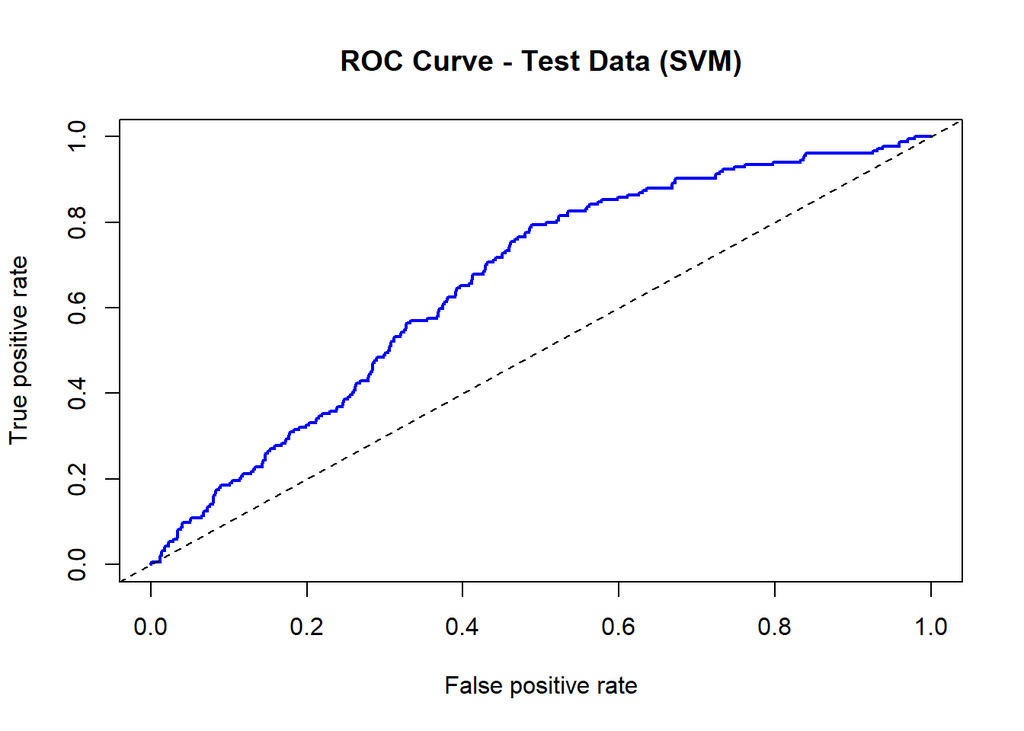

```r
# Predict probabilities for test data
test_pred_svm <- predict(model_svm, test_data, probability = TRUE)
test_pred_prob_svm <- attr(test_pred_svm, "probabilities")[, "1"]

# Plot ROC curve
pred_test_svm <- prediction(test_pred_prob_svm, test_data$bad)
perf_test_svm <- performance(pred_test_svm, "tpr", "fpr")

plot(perf_test_svm, main = "ROC Curve - Test Data (SVM)", col = "blue", lwd = 2)
abline(0, 1, lty = 2)
```

```r
# AUC value for test data
auc_test_svm <- performance(pred_test_svm, "auc")
auc_test_value_svm <- auc_test_svm@y.values[[1]]
cat("AUC (Test Data - SVM):", round(auc_test_value_svm, 4), "\n")
```

```
## AUC (Test Data - SVM): 0.662
```

- The ROC curve for the test data demonstrates weak model performance, with a low AUC of 0.662, suggesting that the SVM model has difficulty in reliably distinguishing between defaulters and non-defaulters.

Obtain Confusion Matrix for test data

```r
test_pred_class_svm <- predict(model_svm, test_data)
confusionMatrix(test_pred_class_svm, as.factor(test_data$bad), positive = "1")
```

```
## Confusion Matrix and Statistics
##
##           Reference
## Prediction    0    1
##          0 1212  184
##          1    0    0
##
##                Accuracy : 0.8682
##                  95% CI : (0.8493, 0.8855)
##     No Information Rate : 0.8682
##     P-Value [Acc > NIR] : 0.5196
##
##                   Kappa : 0
##
##  Mcnemar's Test P-Value : <2e-16
##
##             Sensitivity : 0.0000
##             Specificity : 1.0000
##          Pos Pred Value :    NaN
##          Neg Pred Value : 0.8682
##              Prevalence : 0.1318
##          Detection Rate : 0.0000
##    Detection Prevalence : 0.0000
##       Balanced Accuracy : 0.5000
##
##        'Positive' Class : 1
##
```

- On the test data, the SVM model predicted all customers as non-defaulters, achieving 86.82% accuracy due to the higher presence of non-defaulters in the dataset, with perfect specificity (100%) but no ability to detect actual defaulters (0% sensitivity).

Decision Tree Method

Apply Decision Tree method on Train Data

[figure not shown]

```r
# Importing required library
library(partykit)

model_tree <- ctree(bad ~ ., data = train_data)
plot(model_tree,type="simple", gp = gpar(fontsize = 18, lwd = 2))
```

- The decision tree shows that employment duration, credit card debt, and debt-to-income ratio are the key factors in predicting whether a customer will default. These appear at the top levels of the tree, highlighting their importance.
- Other factors like zone, other debts, and address duration help further split the data and improve classification.

Obtain ROC curve and AUC for train data

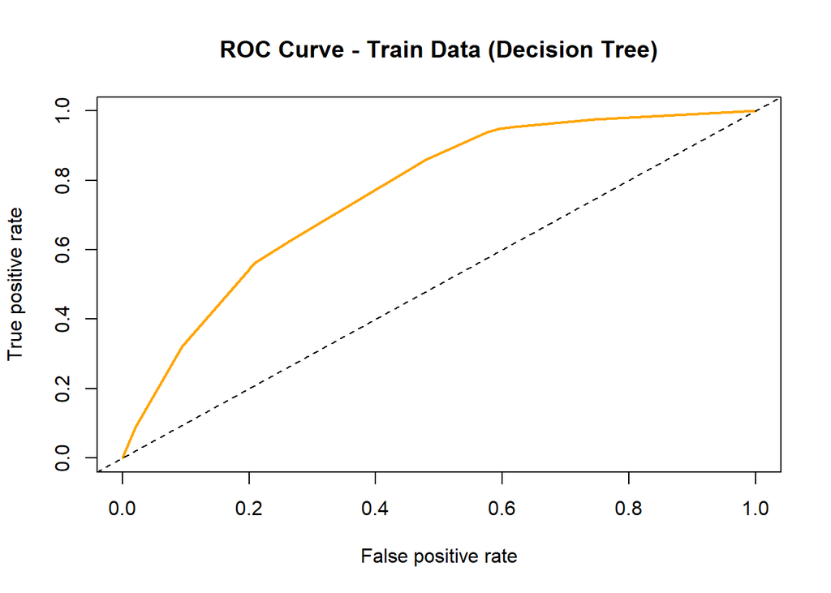

```r
# Predict probabilities for train data
train_pred_prob_tree <- predict(model_tree, train_data, type = "prob")[, "1"]

# Plot ROC curve
pred_train_tree <- prediction(train_pred_prob_tree, train_data$bad)
perf_train_tree <- performance(pred_train_tree, "tpr", "fpr")

plot(perf_train_tree, main = "ROC Curve - Train Data (Decision Tree)", col = "orange", lwd = 2)
abline(0, 1, lty = 2)
```

```r
# AUC value for train data
auc_train_tree <- performance(pred_train_tree, "auc")
auc_train_value_tree <- auc_train_tree@y.values[[1]]
cat("AUC (Train Data - Decision Tree):", round(auc_train_value_tree, 4), "\n")
```

```
## AUC (Train Data - Decision Tree): 0.7602
```

- The ROC curve for the train data shows moderate discriminatory ability with an AUC of 0.7602, indicating a fair separation between defaulters and non-defaulters.

Obtain Confusion Matrix for train data

```r
train_pred_class_tree <- predict(model_tree, train_data)
confusionMatrix(train_pred_class_tree, as.factor(train_data$bad), positive = "1")
```

```
## Confusion Matrix and Statistics
##
##           Reference
## Prediction    0    1
##          0 4847  736
##          1    3    4
##
##                Accuracy : 0.8678
##                  95% CI : (0.8586, 0.8766)
##     No Information Rate : 0.8676
##     P-Value [Acc > NIR] : 0.4941
##
##                   Kappa : 0.0082
##
##  Mcnemar's Test P-Value : <2e-16
##
##             Sensitivity : 0.0054054
##             Specificity : 0.9993814
##          Pos Pred Value : 0.5714286
##          Neg Pred Value : 0.8681712
##              Prevalence : 0.1323792
##          Detection Rate : 0.0007156
##    Detection Prevalence : 0.0012522
##       Balanced Accuracy : 0.5023934
##
##        'Positive' Class : 1
##
```

- Decision Tree model achieved 86.78% accuracy on the train data, with very high specificity (99.9%) but extremely low sensitivity (0.54%), predicting almost all customers as non-defaulters.

Obtain ROC curve and AUC for test data

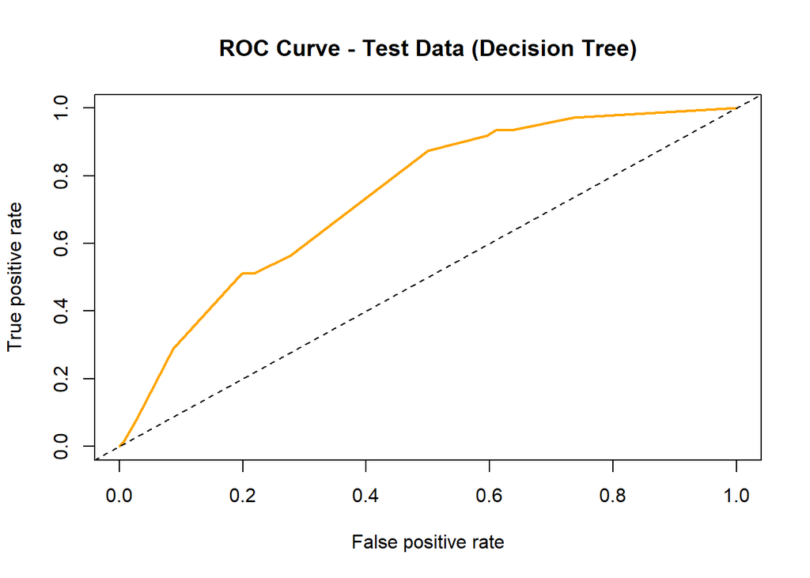

```r
# Predict probabilities for test data
test_pred_prob_tree <- predict(model_tree, test_data, type = "prob")[, "1"]

# Plot ROC curve
pred_test_tree <- prediction(test_pred_prob_tree, test_data$bad)
perf_test_tree <- performance(pred_test_tree, "tpr", "fpr")

plot(perf_test_tree, main = "ROC Curve - Test Data (Decision Tree)", col = "orange", lwd = 2)
abline(0, 1, lty = 2)
```

```r
# AUC value for test data
auc_test_tree <- performance(pred_test_tree, "auc")
auc_test_value_tree <- auc_test_tree@y.values[[1]]
cat("AUC (Test Data - Decision Tree):", round(auc_test_value_tree, 4), "\n")
```

```
## AUC (Test Data - Decision Tree): 0.7381
```

- The ROC curve for the test data indicates moderate model performance with an AUC of 0.7381.

Obtain Confusion Matrix for test data

```r
test_pred_class_tree <- predict(model_tree, test_data)
confusionMatrix(test_pred_class_tree, as.factor(test_data$bad), positive = "1")
```

```
## Confusion Matrix and Statistics
##
##           Reference
## Prediction    0    1
##          0 1205  182
##          1    7    2
##
##                Accuracy : 0.8646
##                  95% CI : (0.8455, 0.8821)
##     No Information Rate : 0.8682
##     P-Value [Acc > NIR] : 0.6711
##
##                   Kappa : 0.0085
##
##  Mcnemar's Test P-Value : <2e-16
##
##             Sensitivity : 0.010870
##             Specificity : 0.994224
##          Pos Pred Value : 0.222222
##          Neg Pred Value : 0.868782
##              Prevalence : 0.131805
##          Detection Rate : 0.001433
##    Detection Prevalence : 0.006447
##       Balanced Accuracy : 0.502547
##
##        'Positive' Class : 1
##
```

- Decision Tree model achieved 86.46% accuracy on the test data, with 99.42% specificity but extremely low sensitivity (1.09%), predicting almost all customers as non-defaulters.

Random Forest Method

Apply Random Forest on Train Data

```r
# Importing required library
library(randomForest)

model_rf <- randomForest(bad ~ ., data = train_data, ntree = 500, mtry = floor(sqrt(ncol(train_data) - 2)), importance = TRUE)

model_rf
```

```
##
## Call:
##  randomForest(formula = bad ~ ., data = train_data, ntree = 500,      mtry = floor(sqrt(ncol(train_data) - 2)), importance = TRUE)
##                Type of random forest: classification
##                      Number of trees: 500
## No. of variables tried at each split: 4
##
##         OOB estimate of  error rate: 13.04%
## Confusion matrix:
##      0  1 class.error
## 0 4833 17 0.003505155
## 1  712 28 0.962162162
```

```r
# Variable Importance Plot
model_rf$importance
```

```
##                      0             1 MeanDecreaseAccuracy MeanDecreaseGini
## veh       2.526223e-04 -6.207995e-04         1.333060e-04         21.64152
## house     1.300533e-04  7.026998e-04         2.107671e-04         20.44702
## selfemp  -1.063421e-04 -1.190390e-03        -2.504244e-04         21.31930
## account   8.520580e-05  1.563195e-03         2.858561e-04         21.71896
## deposit   4.387622e-05  1.887547e-04         7.060582e-05         22.00105
## emp       1.735204e-02  5.398359e-02         2.220206e-02        152.24071
## address   4.313430e-03  2.476559e-02         7.035641e-03        121.24152
## branch    1.006829e-04  2.788067e-03         4.508668e-04         21.16084
## ref      -2.681648e-04  3.985747e-04        -1.779948e-04         20.72288
## debtinc   1.594003e-02  2.840150e-02         1.758545e-02        186.20459
## creddebt  7.675084e-03  8.483649e-03         7.784540e-03        161.64659
## othdebt   1.705460e-02 -2.725001e-03         1.442592e-02        162.29183
## preloan   1.020953e-04 -6.792036e-04         3.154719e-06         21.63456
## age      -3.960682e-04  6.397525e-04        -2.587383e-04         40.63800
## gender    5.522368e-05  1.277421e-04         6.114798e-05         20.70714
## ms        3.488181e-04  9.679281e-05         3.137078e-04         19.73761
## child    -1.726786e-04 -1.725569e-05        -1.547714e-04         15.70184
## zone      2.224502e-03  7.788936e-03         2.967359e-03        226.51188
```

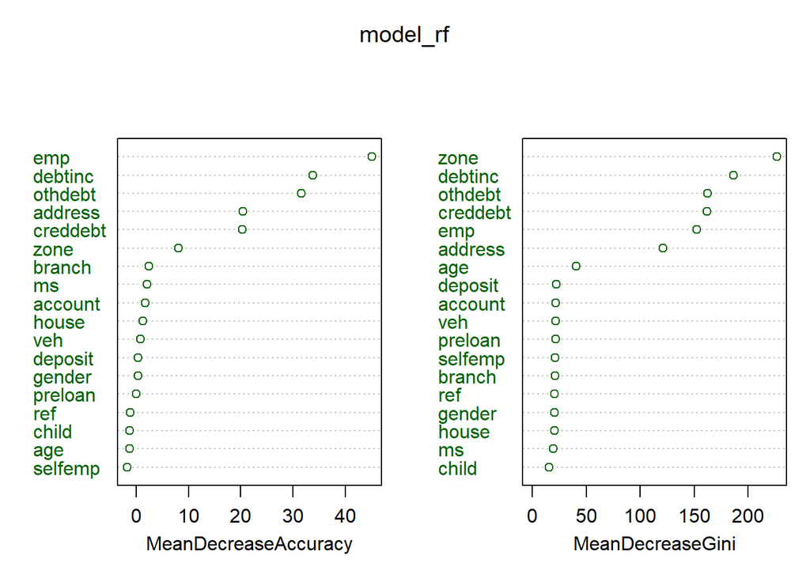

```r
varImpPlot(model_rf,col="darkgreen")
```

- The variable importance plot from the Random Forest model shows that employment duration (emp), loan to income ratio (debtinc), other debts (othdebt), credit card debt (creddebt), and zone are the most influential features in classifying customers.

Obtain ROC curve and AUC for train data

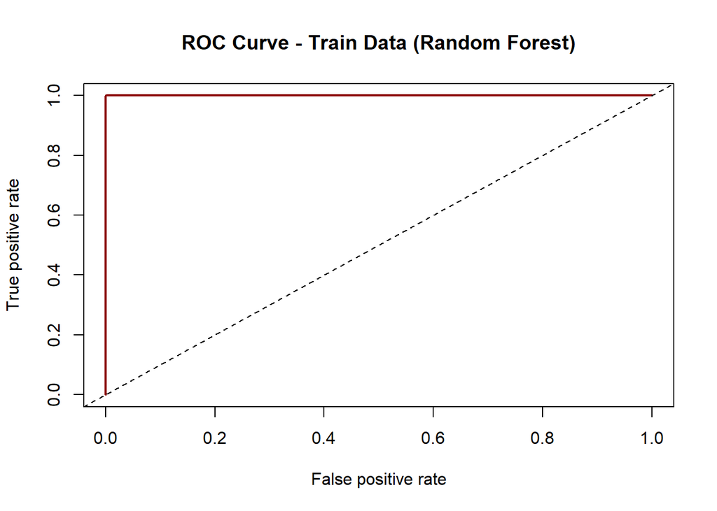

```r
# Predict probabilities for train data
train_pred_prob_rf <- predict(model_rf, train_data, type = "prob")[, "1"]

# Plot ROC curve
pred_train_rf <- prediction(train_pred_prob_rf, train_data$bad)
perf_train_rf <- performance(pred_train_rf, "tpr", "fpr")

plot(perf_train_rf, main = "ROC Curve - Train Data (Random Forest)", col = "darkred", lwd = 2)
abline(0, 1, lty = 2)
```

```r
# AUC value for train data
auc_train_rf <- performance(pred_train_rf, "auc")
auc_train_value_rf <- auc_train_rf@y.values[[1]]
cat("AUC (Train Data - Random Forest):", round(auc_train_value_rf, 4), "\n")
```

```
## AUC (Train Data - Random Forest): 1
```

- The ROC curve for the train data shows perfect model performance with an AUC of 1, indicating complete separation between defaulters and non-defaulters.

Obtain Confusion Matrix for train data

```r
train_pred_class_rf <- predict(model_rf, train_data)
confusionMatrix(train_pred_class_rf, as.factor(train_data$bad), positive = "1")
```

```
## Confusion Matrix and Statistics
##
##           Reference
## Prediction    0    1
##          0 4850    0
##          1    0  740
##
##                Accuracy : 1
##                  95% CI : (0.9993, 1)
##     No Information Rate : 0.8676
##     P-Value [Acc > NIR] : < 2.2e-16
##
##                   Kappa : 1
##
##  Mcnemar's Test P-Value : NA
##
##             Sensitivity : 1.0000
##             Specificity : 1.0000
##          Pos Pred Value : 1.0000
##          Neg Pred Value : 1.0000
##              Prevalence : 0.1324
##          Detection Rate : 0.1324
##    Detection Prevalence : 0.1324
##       Balanced Accuracy : 1.0000
##
##        'Positive' Class : 1
##
```

- On the train data, the Random Forest model achieved 100% accuracy, sensitivity, and specificity, perfectly classifying all customers without any error.

Obtain ROC curve and AUC for test data

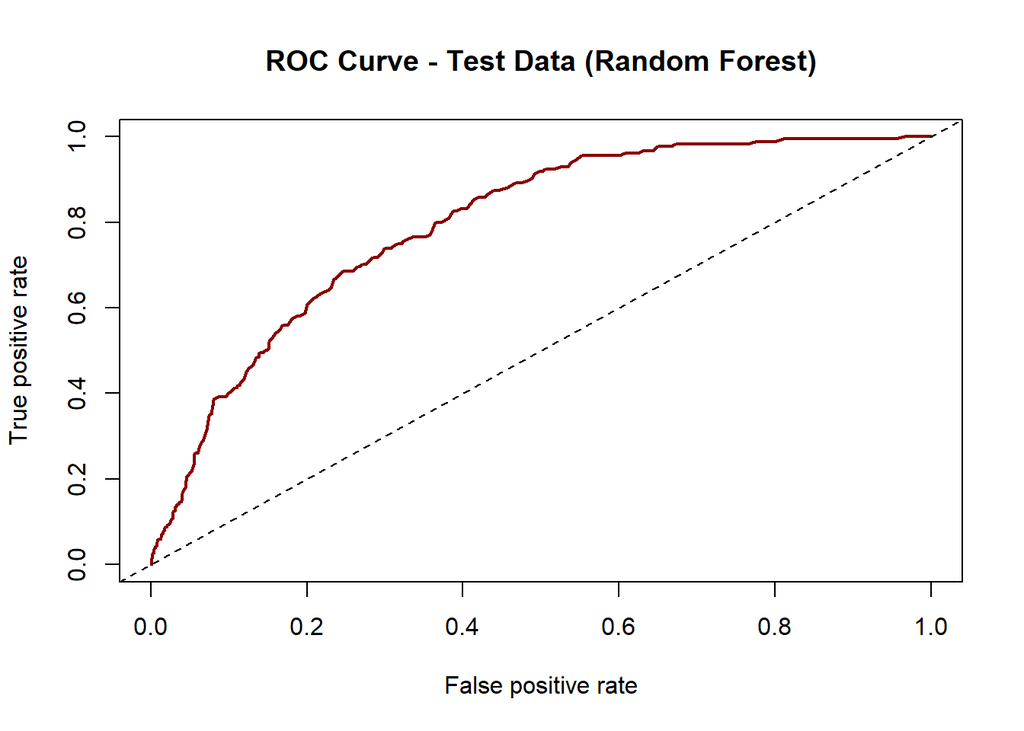

```r
# Predict probabilities for test data
test_pred_prob_rf <- predict(model_rf, test_data, type = "prob")[, "1"]

# Plot ROC curve
pred_test_rf <- prediction(test_pred_prob_rf, test_data$bad)
perf_test_rf <- performance(pred_test_rf, "tpr", "fpr")

plot(perf_test_rf, main = "ROC Curve - Test Data (Random Forest)", col = "darkred", lwd = 2)
abline(0, 1, lty = 2)
```

```r
# AUC value for test data
auc_test_rf <- performance(pred_test_rf, "auc")
auc_test_value_rf <- auc_test_rf@y.values[[1]]
cat("AUC (Test Data - Random Forest):", round(auc_test_value_rf, 4), "\n")
```

```
## AUC (Test Data - Random Forest): 0.7953
```

- The ROC curve for the test data shows strong model performance with an AUC of 0.7953, indicating good separation between defaulters and non-defaulters.

Obtain Confusion Matrix for test data

```r
test_pred_class_rf <- predict(model_rf, test_data)
confusionMatrix(test_pred_class_rf, as.factor(test_data$bad), positive = "1")
```

```
## Confusion Matrix and Statistics
##
##           Reference
## Prediction    0    1
##          0 1207  178
##          1    5    6
##
##                Accuracy : 0.8689
##                  95% CI : (0.8501, 0.8862)
##     No Information Rate : 0.8682
##     P-Value [Acc > NIR] : 0.4881
##
##                   Kappa : 0.0474
##
##  Mcnemar's Test P-Value : <2e-16
##
##             Sensitivity : 0.032609
##             Specificity : 0.995875
##          Pos Pred Value : 0.545455
##          Neg Pred Value : 0.871480
##              Prevalence : 0.131805
##          Detection Rate : 0.004298
##    Detection Prevalence : 0.007880
##       Balanced Accuracy : 0.514242
##
##        'Positive' Class : 1
##
```

- The Random Forest model achieved 86.89% accuracy on the test data, with very high specificity (99.59%) but low sensitivity (3.26%), predicting non-defaulters very well.

Compare AUC for test data in case of all methods and finalize the method

```r
model_names <- c("Logistic Regression", "Naive Bayes", "SVM", "Decision Tree", "Random Forest")
test_auc_values <- c(auc_test_value, auc_test_value_nb, auc_test_value_svm, auc_test_value_tree, auc_test_value_rf)

comparison_table <- data.frame(Model = model_names, Test_AUC = test_auc_values)
comparison_table
```

```
##                 Model  Test_AUC
## 1 Logistic Regression 0.7700486
## 2         Naive Bayes 0.7665465
## 3                 SVM 0.6620345
## 4       Decision Tree 0.7380767
## 5       Random Forest 0.7953302
```

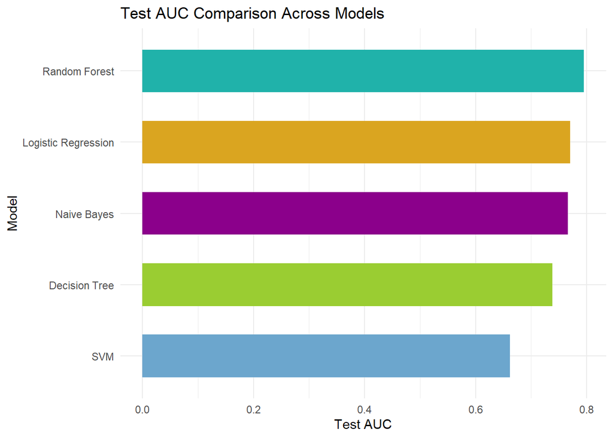

```r
# Horizontal bar plot
ggplot(comparison_table, aes(x = reorder(Model, Test_AUC), y = Test_AUC, fill = Model)) +
  geom_bar(stat = "identity", width = 0.6) +
  coord_flip() +
  labs(title = "Test AUC Comparison Across Models", x = "Model", y = "Test AUC") +
  theme_minimal() +
  scale_fill_manual(values = c("olivedrab3", "goldenrod", "darkmagenta", "lightseagreen", "skyblue3")) +
  theme(legend.position = "none")
```

**Conclusion:** Among these models, the Random Forest model demonstrated the highest test AUC value of 0.7953, indicating strong discriminatory ability.  
Based on test AUC comparison, the Random Forest model is finalized as the best performing method for the classification task.

**Finalized model:** Random Forest (Highest AUC = 0.7953)

Phase 5: Customer Feedback Analysis

1. Text Pre-processing

```r
# Import required libraries
library(tm)
library(dplyr)
library(tidytext)
library(stringr)
library(ggplot2)
library(wordcloud)
library(sentimentr)

# Import and preprocess text data
feedback <- readLines(file.choose())
head(feedback)
```

```
## [1] "My experience of availing the personal loan was smooth."
## [2] "I had a satisfactory experience with the Bank. The loan officer was helpful, and the approval process was quick. However, their interest rates were a bit higher than what I expected."
## [3] "I had an excellent experience with the Bank while applying for a loan. The loan officer was efficient, and I got my loan approved within a few days."
## [4] "I had to move on to another bank as it was taking a long time"
## [5] "I recently applied for a loan at the Bank, and the service was impeccable. They guided me through the entire process and explained all the terms clearly. "
## [6] "I got my loan approved within a few days, and the Interest rate was reasonable. Highly recommended!"
```

```r
# Convert feedback to a data frame and remove any empty lines
feedback <- data.frame(text = feedback, stringsAsFactors = FALSE) %>%
  filter(str_trim(text) != "")

# Create corpus
corpus <- Corpus(VectorSource(feedback$text))

# Clean text - Removing punctuation, numbers, stopwords and extra space
corpus_clean <- corpus %>%
  tm_map(content_transformer(tolower)) %>%
  tm_map(removePunctuation) %>%
  tm_map(removeNumbers) %>%
  tm_map(removeWords, stopwords("english")) %>%
  tm_map(removeWords, c("bank", "loan", "pl", "manager", "officer", "application", "product", "service", "process", "experience")) %>%
  tm_map(stripWhitespace)

# Convert corpus to clean data frame
feedback_clean <- data.frame(text = sapply(corpus_clean, as.character), stringsAsFactors = FALSE)
```

2. Word Cloud

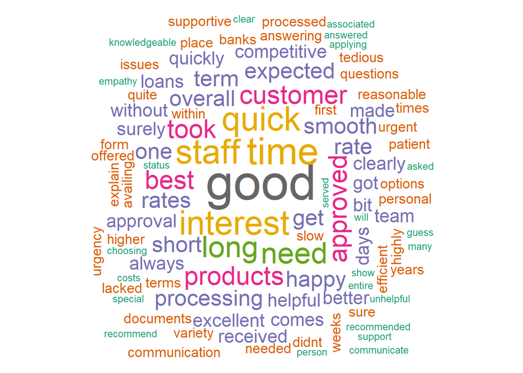

```r
# Create Term-Document Matrix and get word frequencies
tdm <- TermDocumentMatrix(corpus_clean)
m <- as.matrix(tdm)
word_freqs <- sort(rowSums(m), decreasing = TRUE)
word_data <- data.frame(word = names(word_freqs), freq = word_freqs)

# Generate word cloud
set.seed(123)

wordcloud(words = word_data$word, freq = word_data$freq,
          min.freq = 1, max.words = 100,
          scale = c(4, 0.5),
          colors = brewer.pal(8, "Dark2"),
          random.order = FALSE)
```

- The word cloud reveals that customers often referred to experiences with “good” service, “interest” rates, “staff” interactions and “quick” process.
- This suggests that customer feedback primarily reflects perceptions of service quality, efficiency and product satisfaction, which are important to their overall experience.
3. Sentiment Analysis

```r
# Get sentence level sentiment scores
sentiment_result <- sentiment(feedback_clean$text)

# Aggregate scores per feedback entry
sentiment_summary <- sentiment_result %>%
  group_by(element_id) %>%
  summarise(sentiment = mean(sentiment))

## As several feedback entries contained multiple sentences, sentiment analysis was performed at the sentence level and then averaged across each full entry to reflect the overall customer sentiment.

# Combine with original feedback
feedback_with_sentiment <- bind_cols(feedback_clean, sentiment_summary)

# Classify Sentiment into Categories
feedback_with_sentiment <- feedback_with_sentiment %>%
  mutate(sentiment_category = case_when(
    sentiment > 0.1 ~ "Positive",
    sentiment < -0.1 ~ "Negative",
    TRUE ~ "Neutral"
  ))

head(feedback_with_sentiment)
```

```
##                                                                              text
## 1                                                        availing personal smooth
## 2  satisfactory helpful approval quick however interest rates bit higher expected
## 3                           excellent applying efficient got approved within days
## 4                                                   move another taking long time
## 5              recently applied impeccable guided entire explained terms clearly
## 6            got approved within days interest rate reasonable highly recommended
##   element_id sentiment sentiment_category
## 1          1 0.3464102           Positive
## 2          2 0.8465417           Positive
## 3          3 1.0394023           Positive
## 4          4 0.0000000            Neutral
## 5          5 0.3535534           Positive
## 6          6 1.1000000           Positive
```

- Most of the initial feedback entries show a positive sentiment, reflecting customer satisfaction with services like approval speed and guidance.
4. Visualizing Sentiment Scores

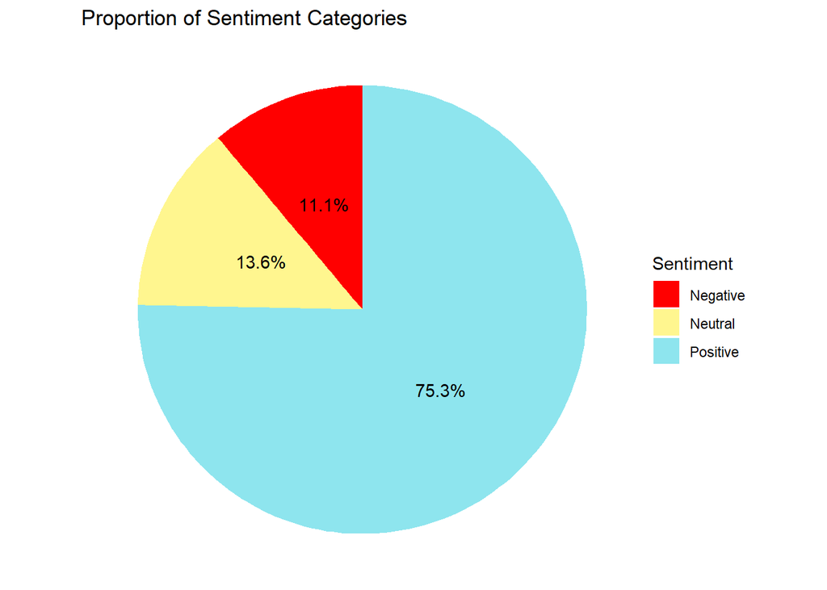

```r
# Pie chart: Sentiment Category Counts
category_counts <- feedback_with_sentiment %>%
  count(sentiment_category)

ggplot(category_counts, aes(x = "", y = n, fill = sentiment_category)) +
  geom_bar(stat = "identity", width = 1) +
  coord_polar("y", start = 0) +
  theme_void() +
  labs(fill = "Sentiment") +
  ggtitle("Proportion of Sentiment Categories") +
  geom_text(aes(label = scales::percent(n / sum(n))),
            position = position_stack(vjust = 0.5)) +
  scale_fill_manual(values = c("Positive" = "cadetblue2",
                                "Negative" = "red",
                                "Neutral"  = "khaki1"))
```

- The pie chart shows that 75.3% of customer feedback is positive, indicating a strong level of satisfaction with the bank’s services.
- In contrast, only 11.1% is negative, while 13.6% remains neutral, suggesting that unfavorable experiences are relatively limited.

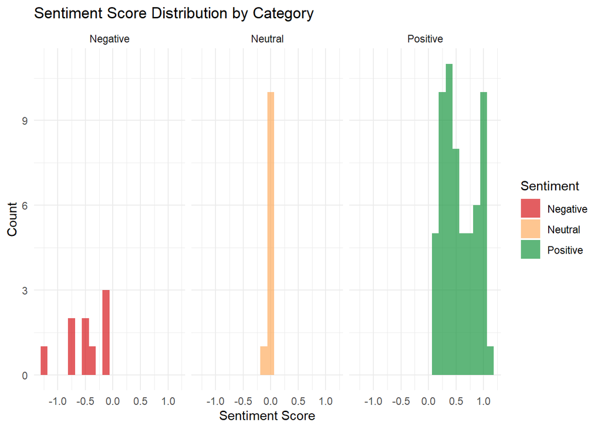

```r
# Faceted Histogram: Sentiment Score Distribution
ggplot(feedback_with_sentiment, aes(x = sentiment, fill = sentiment_category)) +
  geom_histogram(bins = 20, position = "identity", alpha = 0.7) +
  facet_wrap(~ sentiment_category) +
  labs(title = "Sentiment Score Distribution by Category",
       x = "Sentiment Score",
       y = "Count",
       fill = "Sentiment") +
  theme_minimal() +
  scale_fill_manual(values = c("Negative" = "#d7191c",
                               "Neutral"  = "#fdae61",
                               "Positive" = "#1a9641"))
```

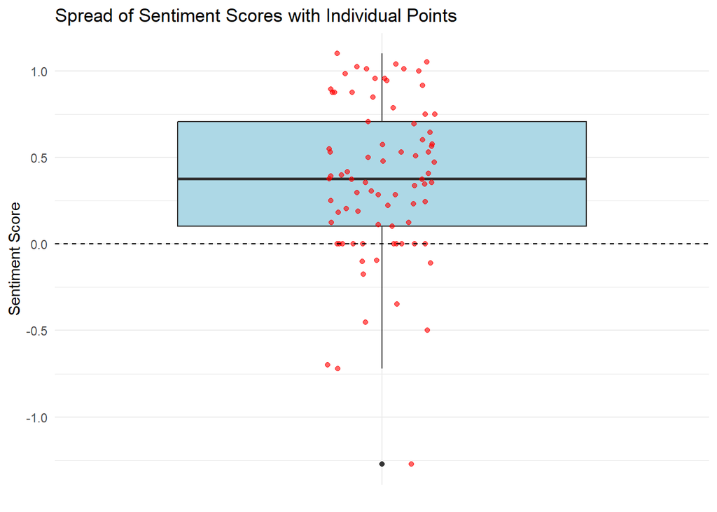

```r
# Boxplot: Spread of Sentiment Scores
ggplot(feedback_with_sentiment, aes(x = "", y = sentiment)) +
  geom_boxplot(fill = "lightblue") +
  geom_jitter(width = 0.1, alpha = 0.6, color = "red") +
  geom_hline(yintercept = 0, linetype = "dashed", color = "black") +
  labs(
    title = "Spread of Sentiment Scores with Individual Points",
    x = NULL,
    y = "Sentiment Score"
  ) +
  theme_minimal()
```

- The boxplot illustrates that most sentiment scores cluster above zero, with a median well into the positive range, indicating overall favorable customer feedback.
- A few outliers fall below zero, showing some isolated negative sentiments, but they are relatively rare compared to the volume of positive responses.

Analyze Negative Feedback

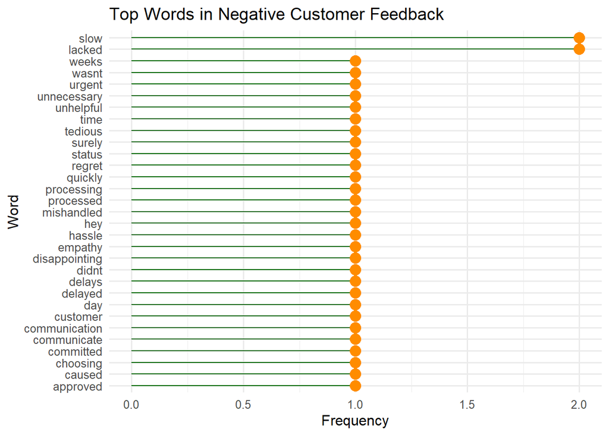

```r
# Load stop words
data("stop_words")

# Filter only negative feedback
negative_feedback <- feedback_with_sentiment %>%
  filter(sentiment_category == "Negative")

# Tokenize and remove stopwords
negative_words <- negative_feedback %>%
  unnest_tokens(word, text) %>%
  anti_join(stop_words, by = "word") %>%
  count(word, sort = TRUE)

# Select top 10 negative words
top_negative_words <- negative_words %>%
  top_n(10, n) %>%
  arrange(n)

# Lollipop chart
ggplot(top_negative_words, aes(x = reorder(word, n), y = n)) +
  geom_segment(aes(xend = word, y = 0, yend = n), color = "darkgreen") +
  geom_point(size = 4, color = "darkorange") +
  coord_flip() +
  labs(title = "Top Words in Negative Customer Feedback",
       x = "Word",
       y = "Frequency") +
  theme_minimal(base_size = 12)
```

- The lollipop chart highlights commonly used words in negative customer feedback, such as “slow” and “lacked”, which indicate that dissatisfaction mainly arises from delays and lack of proactive support.

**Conclusion:**

- The customer feedback analysis revealed that over 75% of responses were positive, emphasizing service satisfaction.
- However, critical insights from negative feedback highlighted operational gaps in the bank’s service delivery and suggesting the need for process improvements and enhanced staff responsiveness to better meet customer expectations.